# Annual Total BC Dissimilarity vs. SODA Temperature for all Survey Units

- This project is a collaborative effort to describe changes in taxonomic composition of fish communities around the world–as sampled by bottom trawl surveys.
- Code by Zoë J. Kitchel

##Here, we use bottom temperature to predict annual dissimilarity for all survey units

```r
library(data.table)
library(ggplot2)
library(lme4)
library(lmerTest)
library(MuMIn)


SODA_data_temp_avgs_full <- readRDS(here::here("data","Temperature","SODA_data_temp_avgs_full.rds"))
#don't feel confident about SODA temp before 1980 right now, start then

SODA_data_temp_avgs_full <- SODA_data_temp_avgs_full[year_for_avg >= 1980,]

SODA_data_temp_avgs_full[,year := year_for_avg]

#pull in average distance decay values
distances_dissimilarities_allyears.r <- readRDS(here::here("output","dissimilarities","distances_dissimilarities_allyears.r.rds"))
```

Model to extract p value from overall model

```r
#define function to extract overall p-value of model
overall_p <- function(my_model) {
    f <- summary(my_model)$fstatistic
    p <- pf(f[1],f[2],f[3],lower.tail=F)
    attributes(p) <- NULL
    return(p)
}
```

```r
name_helper <- data.table(Survey_Name_Season = c("Aleutian Islands",
                                    "Baltic Sea Q1",
                                    "Baltic Sea Q4",
                                    "Chile",
                                    "Newfoundland",
                                    "Queen Charlotte Sound",
                                    "Eastern Bering Sea",
                                    "Bay of Biscay",
                                    "English Channel",
                                    "Gulf of Mexico Summer",
                                    "Gulf of Alaska",
                                    "Greenland",
                                    "N Gulf of St. Lawrence",
                                    "S Gulf of St. Lawrence",
                                    "Iceland",
                                    "Irish Sea",
                                    "Mediterranean",
                                    "Namibia",
                                    "NE US Fall",
                                    "NE US Spring",
                                    "N Ireland Q1",
                                    "N Ireland Q4",
                                    "Barents Sea Norway Q3",
                                    "N Sea Q1",
                                    "N Sea Q3",
                                    "Chatham Rise NZ",
                                    "E Coast S Island NZ",
                                    "W Coast S Island NZ",
                                    "Portugal",
                                    "S Georgia",
                                  "Scotian Shelf Summer",
                                  "SE US Fall",
                                  "SE US Spring",
                                  "SE US Summer",
                                  "W Coast US",
                                  "Atlantic Ocean ZA",
                                  "Indian Ocean ZA",
                                   "Rockall Plateau",
                                  "Scotland Shelf Sea Q1",
                                  "Scotland Shelf Sea Q4",
                                  "Falkland Islands",
                                  "Gulf of Mexico Fall",
                                  "Barents Sea Norway Q1",
                                  "Sub-Arctic NZ",
                                  "Scotian Shelf Spring"),
                          survey_unit = c(
                                  "AI",
                                  "BITS-1",
                                  "BITS-4",
                                  "CHL",
                                  "DFO-NF",
                                  "DFO-QCS",
                                  "EBS",
                                  "EVHOE",
                                  "FR-CGFS",
                                  "GMEX-Summer",
                                  "GOA",
                                  "GRL-DE",
                                  "GSL-N",
                                  "GSL-S",
                                  "ICE-GFS",
                                  "IE-IGFS",
                                  "MEDITS",
                                  "NAM",
                                  "NEUS-Fall",
                                  "NEUS-Spring",
                                  "NIGFS-1",
                                  "NIGFS-4",
                                  "Nor-BTS-3",
                                  "NS-IBTS-1",
                                  "NS-IBTS-3",
                                  "NZ-CHAT",
                                  "NZ-ECSI",
                                  "NZ-WCSI",
                                  "PT-IBTS",
                                  "S-GEORG",
                                  "SCS-SUMMER",
                                  "SEUS-fall",
                                  "SEUS-spring",
                                  "SEUS-summer",
                                  "WCANN",
                                  "ZAF-ATL",
                                  "ZAF-IND",
                                  "ROCKALL",
                                  "SWC-IBTS-1",
                                  "SWC-IBTS-4",
                                  "FALK",
                                  "GMEX-Fall",
                                  "Nor-BTS-1",
                                  "NZ-SUBA",
                                  "SCS-SPRING"
                          ))
```

Color link

```r
survey_unit.list <- levels(factor(distances_dissimilarities_allyears.r[,survey_unit]))

palette_42 <- c(
  "#5A5156", #AI
  "#DF00DB", #BITS-1
  "#DB8EDA", #BITS-4
  "#F6222E", #CHL
  "#F8A19F", #DFO-NF
  "#16FF32", #DFO-QCS
  "#325A9B", #EBS
  "#3283FE", #EVHOE
  "#FEAF16", #FR-CGFS
  "#fccb6d", #GMEX-Fall
  "#1C8356", #GMEX-Summer
  "#C4451C", #GOA
  "#85660D", #GRL-DE
  "#B0009F", #GSL-N
  "#BF79B8", #GSL-S
  "#1CBE4F", #ICE-GFS
  "#782AB6", #IE-IGFS
  "#90AD1C", #MEDITS
  "#6B003A", #NAM
  "#A75B00", #NEUS-Fall
  "#E3B072", #NEUS-Spring
  "#02E8B6", #NIGFS-1
  "#97E7D5", #NIGFS-4
  "#B00068", #Nor-BTS-3
  "#00B9E3", #NS-IBTS-1
  "#95E2F4", #NS-IBTS-3
  "#B3CE73", #NZ-CHAT
  "#689500", #NZ-ECSI
  "#364d02",#NZ-SUBA
  "#AAF400", #NZ-WCSI
  "#AA0DFE", #PT-IBTS
  "#7f9eb8", #ROCKALL
  "#FA0087", #S-GEORG
  "#DEA0FD", #SCS-Summer
  "#FCEF88", #SEUS-fall
  "#A59405", #SEUS-spring
  "#FCE100", #SEUS-summer
  "#544563", #SWC-IBTS-1
  "#a37fc7", #SWC-IBTS-4
  "#C075A6", #WCANN
  "#BDCDFF", #ZAF-ATL
  "#003EFF"  #ZAF-IND
)

color_link <- data.table(survey_unit = survey_unit.list,hex = palette_42)

color_link <- name_helper[color_link, on = "survey_unit", nomatch = NULL]
```

Put into one data table

```r
dissimilarities_temp <- SODA_data_temp_avgs_full[distances_dissimilarities_allyears.r, on = c("year","survey_unit")]
```

Pull in dissimilarity ~ model coefficients

```r
BC_total_model_coefs_reduced_length.unique <- readRDS(here::here("output","region_stats","BC_total_model_coefs_reduced_length.unique.Rds"))
```

Table that will be populated with model results

```r
#depth, scaled, temp var, coefficient, p-value, r^2, AICc
total_dissimilarity_sbt_model_results <- data.table(Depth = as.character(),
                                                       Scaled = as.character(),
                                                       `Temp variable` = as.character(),
                                                       Intercept = as.numeric(),
                                                       `Temp coefficient` = as.numeric(),
                                                       `Model p-value` = as.numeric(),
                                                       `R-squared` = as.numeric(),
                                                       AICc = as.numeric())
```

How does this trend hold up for all regions? ###UNSCALED

####Mean temperature

```r
#for all regions
(dissimilarity_BC_total_sbt_mean <- ggplot(data = dissimilarities_temp) +
  labs(x = "Mean bottom temperature (˚C)",  y = "Bray Curtis total dissimilarity") +
  geom_point(aes(x = yearly_mean_bypoint_avg, y = bray_curtis_dissimilarity_total_mean, color = survey_unit), alpha = 0.3) +
  geom_line(aes(x = yearly_mean_bypoint_avg, y = bray_curtis_dissimilarity_total_mean, color = survey_unit), stat="smooth", method = "lm") +
  scale_color_manual(values = c(palette_42)) +
  geom_smooth(aes(x = yearly_mean_bypoint_avg, y = bray_curtis_dissimilarity_total_mean), method = "lm", se = F, color  = "black") +
  theme_classic())

ggsave(dissimilarity_BC_total_sbt_mean, path  = here::here("figures","distance_decay"), filename = "dissimilarity_BC_total_sbt_mean.jpg", height = 4, width = 9, unit = "in")

dissimilarity_BC_total_sbt_mean_facet <- ggplot(data = dissimilarities_temp) +
  labs(x = "Mean bottom temperature (˚C)",  y = "Bray Curtis total dissimilarity") +
  geom_point(aes(x = yearly_mean_bypoint_avg, y = bray_curtis_dissimilarity_total_mean), alpha = 0.3) +
  geom_smooth(aes(x = yearly_mean_bypoint_avg, y = bray_curtis_dissimilarity_total_mean), method = "lm") +
  facet_wrap(~survey_unit, scales = "free") +
  theme_classic()

ggsave(dissimilarity_BC_total_sbt_mean_facet, path  = here::here("figures","distance_decay"), filename = "dissimilarity_BC_total_sbt_mean_facet.jpg", height = 10, width = 11, unit = "in")

dissimilarity_BC_total_sbt_mean_mod <- lm(bray_curtis_dissimilarity_total_mean ~ yearly_mean_bypoint_avg, data = dissimilarities_temp) #this converges (allows both intercept and slope to vary with survey_unit)

summary(dissimilarity_BC_total_sbt_mean_mod) #insignificant relationship

confint <- confint(dissimilarity_BC_total_sbt_mean_mod) #confidence interval

coefs <- data.frame(coef(summary(dissimilarity_BC_total_sbt_mean_mod))) #table with coefficients, #Satterthwaite's degrees of freedom, and p-value approximation for fixed effects

#input results into table
total_dissimilarity_sbt_model_results_row <- data.table(matrix(c("sbt", #depth
                                                 F, #scaled
                                                 "yearly_mean_bypoint_avg", #model structure
                                                 paste0(round(coef(dissimilarity_BC_total_sbt_mean_mod)[[1]],3),
                                                        " ± ",
                                                        round((confint[1,2]-confint[1,1])/2,3)), #intercept
                                                 paste0(round(coef(dissimilarity_BC_total_sbt_mean_mod)[[2]],3),
                                                        " ± ",
                                                        round((confint[2,2]-confint[2,1])/2,3)), #coef
                                                 round(coefs[2,4],3), #pvalue
                                                 round(summary(dissimilarity_BC_total_sbt_mean_mod)$r.squared,3),#rsquared
                                                 round(AICc(dissimilarity_BC_total_sbt_mean_mod),3)
                                                 ),nrow = 1))

#merge with larger table
total_dissimilarity_sbt_model_results <- rbind(total_dissimilarity_sbt_model_results,total_dissimilarity_sbt_model_results_row, use.names = F)

#########################
#MEAN TEMP PLUS SURVEY UNIT
#########################
dissimilarity_BC_total_sbt_mean_plus_survey_mod <- lm(bray_curtis_dissimilarity_total_mean ~ yearly_mean_bypoint_avg + survey_unit, data = dissimilarities_temp) #this converges (allows both intercept and slope to vary with survey_unit)

summary(dissimilarity_BC_total_sbt_mean_plus_survey_mod) #insignificant relationship

confint <- confint(dissimilarity_BC_total_sbt_mean_plus_survey_mod) #confidence interval

coefs <- data.frame(coef(summary(dissimilarity_BC_total_sbt_mean_plus_survey_mod))) #table with coefficients, #Satterthwaite's degrees of freedom, and p-value approximation for fixed effects

#input results into table
total_dissimilarity_sbt_model_results_row <- data.table(matrix(c("sbt", #depth
                                                 F, #scaled
                                                 "yearly_mean_bypoint_avg + survey_unit", #model structure
                                                 paste0(round(coef(dissimilarity_BC_total_sbt_mean_plus_survey_mod)[[1]],3),
                                                        " ± ",
                                                        round((confint[1,2]-confint[1,1])/2,3)), #intercept
                                                 paste0(round(coef(dissimilarity_BC_total_sbt_mean_plus_survey_mod)[[2]],3),
                                                        " ± ",
                                                        round((confint[2,2]-confint[2,1])/2,3)), #coef
                                                 signif(overall_p(dissimilarity_BC_total_sbt_mean_plus_survey_mod),2), #model pvalue
                                                 round(summary(dissimilarity_BC_total_sbt_mean_plus_survey_mod)$r.squared,3),#rsquared
                                                 round(AICc(dissimilarity_BC_total_sbt_mean_plus_survey_mod),3)
                                                 ),nrow = 1))

#merge with larger table
total_dissimilarity_sbt_model_results <- rbind(total_dissimilarity_sbt_model_results,total_dissimilarity_sbt_model_results_row, use.names = F)

#########################
#MEAN TEMP * SURVEY UNIT
#########################
dissimilarity_BC_total_sbt_mean_times_survey_mod <- lm(bray_curtis_dissimilarity_total_mean ~ yearly_mean_bypoint_avg * survey_unit, data = dissimilarities_temp) #this converges (allows both intercept and slope to vary with survey_unit)

summary(dissimilarity_BC_total_sbt_mean_times_survey_mod) #insignificant relationship

confint <- confint(dissimilarity_BC_total_sbt_mean_times_survey_mod) #confidence interval

coefs <- data.frame(coef(summary(dissimilarity_BC_total_sbt_mean_times_survey_mod))) #table with coefficients, #Satterthwaite's degrees of freedom, and p-value approximation for fixed effects

#input results into table
total_dissimilarity_sbt_model_results_row <- data.table(matrix(c("sbt", #depth
                                                 F, #scaled
                                                 "yearly_mean_bypoint_avg * survey_unit", #model structure
                                                 paste0(round(coef(dissimilarity_BC_total_sbt_mean_times_survey_mod)[[1]],3),
                                                        " ± ",
                                                        round((confint[1,2]-confint[1,1])/2,3)), #intercept
                                                 paste0(round(coef(dissimilarity_BC_total_sbt_mean_times_survey_mod)[[2]],3),
                                                        " ± ",
                                                        round((confint[2,2]-confint[2,1])/2,3)), #coef
                                                 signif(overall_p(dissimilarity_BC_total_sbt_mean_times_survey_mod),2), #model pvalue
                                                 round(summary(dissimilarity_BC_total_sbt_mean_times_survey_mod)$r.squared,3),#rsquared
                                                 round(AICc(dissimilarity_BC_total_sbt_mean_times_survey_mod),3)
                                                 ),nrow = 1))

#merge with larger table
total_dissimilarity_sbt_model_results <- rbind(total_dissimilarity_sbt_model_results,total_dissimilarity_sbt_model_results_row, use.names = F)
```

[output not shown]

####Min temperature

```r
#for all regions
(dissimilarity_BC_total_sbt_min <- ggplot(data = dissimilarities_temp) +
  labs(x = "min bottom temperature (˚C)",  y = "Bray Curtis total dissimilarity") +
  geom_point(aes(x = yearly_min_bypoint_avg, y = bray_curtis_dissimilarity_total_mean, color = survey_unit), alpha = 0.3) +
  geom_line(aes(x = yearly_min_bypoint_avg, y = bray_curtis_dissimilarity_total_mean, color = survey_unit), stat="smooth", method = "lm") +
  scale_color_manual(values = c(palette_42)) +
  geom_smooth(aes(x = yearly_min_bypoint_avg, y = bray_curtis_dissimilarity_total_mean), method = "lm", se = F, color  = "black") +
  theme_classic())

ggsave(dissimilarity_BC_total_sbt_min, path  = here::here("figures","distance_decay"), filename = "dissimilarity_BC_total_sbt_min.jpg", height = 4, width = 9, unit = "in")
```

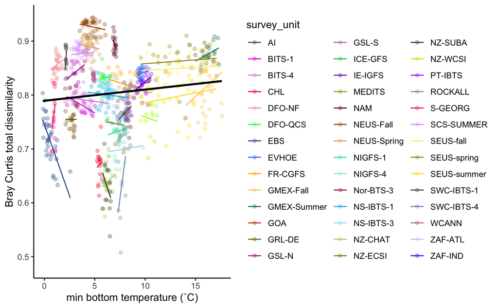

```r
dissimilarity_BC_total_sbt_min_facet <- ggplot(data = dissimilarities_temp) +
  labs(x = "min bottom temperature (˚C)",  y = "Bray Curtis total dissimilarity") +
  geom_point(aes(x = yearly_min_bypoint_avg, y = bray_curtis_dissimilarity_total_mean), alpha = 0.3) +
  geom_smooth(aes(x = yearly_min_bypoint_avg, y = bray_curtis_dissimilarity_total_mean), method = "lm") +
  facet_wrap(~survey_unit, scales = "free") +
  theme_classic()

ggsave(dissimilarity_BC_total_sbt_min_facet, path  = here::here("figures","distance_decay"), filename = "dissimilarity_BC_total_sbt_min_facet.jpg", height = 10, width = 11, unit = "in")
```

```r
dissimilarity_BC_total_sbt_min_mod <- lm(bray_curtis_dissimilarity_total_mean ~ yearly_min_bypoint_avg, data = dissimilarities_temp) #this converges (allows both intercept and slope to vary with survey_unit)

summary(dissimilarity_BC_total_sbt_min_mod) #insignificant relationship
```

```
Call:
lm(formula = bray_curtis_dissimilarity_total_mean ~ yearly_min_bypoint_avg,
    data = dissimilarities_temp)

Residuals:
      Min        1Q    Median        3Q       Max
-0.297379 -0.044926  0.009959  0.053580  0.144461

Coefficients:
                        Estimate Std. Error t value Pr(>|t|)
(Intercept)            0.7893446  0.0053489 147.571  < 2e-16 ***
yearly_min_bypoint_avg 0.0020764  0.0006413   3.238  0.00126 **
---
Signif. codes:  0 ‘***’ 0.001 ‘**’ 0.01 ‘*’ 0.05 ‘.’ 0.1 ‘ ’ 1

Residual standard error: 0.0771 on 751 degrees of freedom
  (144 observations deleted due to missingness)
Multiple R-squared:  0.01377,   Adjusted R-squared:  0.01245
F-statistic: 10.48 on 1 and 751 DF,  p-value: 0.001258
```

```r
confint <- confint(dissimilarity_BC_total_sbt_min_mod) #confidence interval

coefs <- data.frame(coef(summary(dissimilarity_BC_total_sbt_min_mod))) #table with coefficients, #Satterthwaite's degrees of freedom, and p-value approximation for fixed effects

#input results into table
total_dissimilarity_sbt_model_results_row <- data.table(matrix(c("sbt", #depth
                                                 F, #scaled
                                                 "yearly_min_bypoint_avg", #model structure
                                                 paste0(round(coef(dissimilarity_BC_total_sbt_min_mod)[[1]],3),
                                                        " ± ",
                                                        round((confint[1,2]-confint[1,1])/2,3)), #intercept
                                                 paste0(round(coef(dissimilarity_BC_total_sbt_min_mod)[[2]],3),
                                                        " ± ",
                                                        round((confint[2,2]-confint[2,1])/2,3)), #coef
                                                 round(coefs[2,4],3), #pvalue
                                                 round(summary(dissimilarity_BC_total_sbt_min_mod)$r.squared,3),#rsquared
                                                 round(AICc(dissimilarity_BC_total_sbt_min_mod),3)
                                                 ),nrow = 1))

#merge with larger table
total_dissimilarity_sbt_model_results <- rbind(total_dissimilarity_sbt_model_results,total_dissimilarity_sbt_model_results_row, use.names = F)

#########################
#min TEMP PLUS SURVEY UNIT
#########################
dissimilarity_BC_total_sbt_min_plus_survey_mod <- lm(bray_curtis_dissimilarity_total_mean ~ yearly_min_bypoint_avg + survey_unit, data = dissimilarities_temp) #this converges (allows both intercept and slope to vary with survey_unit)

summary(dissimilarity_BC_total_sbt_min_plus_survey_mod) #insignificant relationship
```

```
Call:
lm(formula = bray_curtis_dissimilarity_total_mean ~ yearly_min_bypoint_avg +
    survey_unit, data = dissimilarities_temp)

Residuals:
      Min        1Q    Median        3Q       Max
-0.127981 -0.013244  0.002098  0.013998  0.129565

Coefficients:
                         Estimate Std. Error t value Pr(>|t|)
(Intercept)             0.8638147  0.0081870 105.511  < 2e-16 ***
yearly_min_bypoint_avg  0.0007554  0.0012016   0.629 0.529774
survey_unitBITS-1      -0.0852018  0.0102619  -8.303 5.07e-16 ***
survey_unitBITS-4      -0.0750683  0.0102700  -7.309 7.18e-13 ***
survey_unitCHL         -0.1978871  0.0112013 -17.666  < 2e-16 ***
survey_unitDFO-NF      -0.0082351  0.0097086  -0.848 0.396597
survey_unitDFO-QCS     -0.0369734  0.0126062  -2.933 0.003465 **
survey_unitEBS         -0.1475353  0.0092726 -15.911  < 2e-16 ***
survey_unitEVHOE       -0.0310933  0.0132823  -2.341 0.019508 *
survey_unitFR-CGFS     -0.0503982  0.0120845  -4.170 3.41e-05 ***
survey_unitGMEX-Fall   -0.0608656  0.0190847  -3.189 0.001489 **
survey_unitGMEX-Summer  0.0002670  0.0196553   0.014 0.989165
survey_unitGRL-DE      -0.1110827  0.0097549 -11.387  < 2e-16 ***
survey_unitGSL-N       -0.0212539  0.0108779  -1.954 0.051107 .
survey_unitIE-IGFS     -0.0555785  0.0139052  -3.997 7.08e-05 ***
survey_unitNAM          0.0243885  0.0119744   2.037 0.042044 *
survey_unitNEUS-Fall    0.0598120  0.0095171   6.285 5.71e-10 ***
survey_unitNEUS-Spring  0.0230984  0.0094212   2.452 0.014454 *
survey_unitNIGFS-1     -0.1360316  0.0128809 -10.561  < 2e-16 ***
survey_unitNIGFS-4     -0.1707491  0.0132213 -12.915  < 2e-16 ***
survey_unitNS-IBTS-1   -0.0673719  0.0101474  -6.639 6.23e-11 ***
survey_unitNS-IBTS-3   -0.0515328  0.0109524  -4.705 3.04e-06 ***
survey_unitNZ-CHAT     -0.2293680  0.0109168 -21.010  < 2e-16 ***
survey_unitNZ-ECSI     -0.1234523  0.0128533  -9.605  < 2e-16 ***
survey_unitNZ-SUBA     -0.2394436  0.0117093 -20.449  < 2e-16 ***
survey_unitNZ-WCSI     -0.1162806  0.0150923  -7.705 4.38e-14 ***
survey_unitPT-IBTS     -0.0490357  0.0145421  -3.372 0.000786 ***
survey_unitROCKALL     -0.2338554  0.0138711 -16.859  < 2e-16 ***
survey_unitS-GEORG     -0.1004077  0.0107197  -9.367  < 2e-16 ***
survey_unitSCS-SUMMER   0.0101645  0.0093730   1.084 0.278534
survey_unitSEUS-fall   -0.0244259  0.0166528  -1.467 0.142877
survey_unitSEUS-spring -0.0109031  0.0165099  -0.660 0.509211
survey_unitSEUS-summer -0.0755570  0.0165012  -4.579 5.51e-06 ***
survey_unitSWC-IBTS-1  -0.1002128  0.0119966  -8.353 3.43e-16 ***
survey_unitSWC-IBTS-4  -0.1039202  0.0124826  -8.325 4.26e-16 ***
survey_unitWCANN       -0.0325152  0.0109736  -2.963 0.003147 **
survey_unitZAF-ATL     -0.1159252  0.0120927  -9.586  < 2e-16 ***
---
Signif. codes:  0 ‘***’ 0.001 ‘**’ 0.01 ‘*’ 0.05 ‘.’ 0.1 ‘ ’ 1

Residual standard error: 0.02803 on 716 degrees of freedom
  (144 observations deleted due to missingness)
Multiple R-squared:  0.8757,    Adjusted R-squared:  0.8694
F-statistic: 140.1 on 36 and 716 DF,  p-value: < 2.2e-16
```

```r
confint <- confint(dissimilarity_BC_total_sbt_min_plus_survey_mod) #confidence interval

coefs <- data.frame(coef(summary(dissimilarity_BC_total_sbt_min_plus_survey_mod))) #table with coefficients, #Satterthwaite's degrees of freedom, and p-value approximation for fixed effects

#input results into table
total_dissimilarity_sbt_model_results_row <- data.table(matrix(c("sbt", #depth
                                                 F, #scaled
                                                 "yearly_min_bypoint_avg + survey_unit", #model structure
                                                 paste0(round(coef(dissimilarity_BC_total_sbt_min_plus_survey_mod)[[1]],3),
                                                        " ± ",
                                                        round((confint[1,2]-confint[1,1])/2,3)), #intercept
                                                 paste0(round(coef(dissimilarity_BC_total_sbt_min_plus_survey_mod)[[2]],3),
                                                        " ± ",
                                                        round((confint[2,2]-confint[2,1])/2,3)), #coef
                                                 overall_p(dissimilarity_BC_total_sbt_min_plus_survey_mod), #model pvalue
                                                 round(summary(dissimilarity_BC_total_sbt_min_plus_survey_mod)$r.squared,3),#rsquared
                                                 round(AICc(dissimilarity_BC_total_sbt_min_plus_survey_mod),3)
                                                 ),nrow = 1))

#merge with larger table
total_dissimilarity_sbt_model_results <- rbind(total_dissimilarity_sbt_model_results,total_dissimilarity_sbt_model_results_row, use.names = F)

#########################
#min TEMP * SURVEY UNIT
#########################
dissimilarity_BC_total_sbt_min_times_survey_mod <- lm(bray_curtis_dissimilarity_total_mean ~ yearly_min_bypoint_avg * survey_unit, data = dissimilarities_temp) #this converges (allows both intercept and slope to vary with survey_unit)

summary(dissimilarity_BC_total_sbt_min_times_survey_mod) #insignificant relationship
```

```
Call:
lm(formula = bray_curtis_dissimilarity_total_mean ~ yearly_min_bypoint_avg *
    survey_unit, data = dissimilarities_temp)

Residuals:
      Min        1Q    Median        3Q       Max
-0.111611 -0.012035  0.001687  0.013690  0.094403

Coefficients:
                                              Estimate Std. Error t value Pr(>|t|)
(Intercept)                                     0.2611     0.5044   0.518    0.605
yearly_min_bypoint_avg                          0.2832     0.2363   1.198    0.231
survey_unitBITS-1                               0.5612     0.5053   1.111    0.267
survey_unitBITS-4                               0.5405     0.5050   1.070    0.285
survey_unitCHL                                  0.3023     0.5779   0.523    0.601
survey_unitDFO-NF                               0.5755     0.5053   1.139    0.255
survey_unitDFO-QCS                              0.5508     0.5372   1.025    0.306
survey_unitEBS                                  0.4838     0.5044   0.959    0.338
survey_unitEVHOE                                0.5160     0.5569   0.927    0.354
survey_unitFR-CGFS                              0.6066     0.5064   1.198    0.231
survey_unitGMEX-Fall                            0.2781     0.5134   0.542    0.588
survey_unitGMEX-Summer                          0.4431     0.5297   0.837    0.403
survey_unitGRL-DE                               0.4935     0.5071   0.973    0.331
survey_unitGSL-N                                0.5354     0.5068   1.056    0.291
survey_unitIE-IGFS                              0.4047     0.5293   0.765    0.445
survey_unitNAM                                  1.0466     0.6839   1.530    0.126
survey_unitNEUS-Fall                            0.6846     0.5055   1.354    0.176
survey_unitNEUS-Spring                          0.6497     0.5061   1.284    0.200
survey_unitNIGFS-1                              0.4243     0.5170   0.821    0.412
survey_unitNIGFS-4                              0.4135     0.5097   0.811    0.418
survey_unitNS-IBTS-1                            0.5549     0.5056   1.097    0.273
survey_unitNS-IBTS-3                            0.6408     0.5108   1.255    0.210
survey_unitNZ-CHAT                              0.2664     0.5180   0.514    0.607
survey_unitNZ-ECSI                              0.5125     0.5218   0.982    0.326
survey_unitNZ-SUBA                              0.7313     0.5316   1.376    0.169
survey_unitNZ-WCSI                              0.5636     0.5384   1.047    0.296
survey_unitPT-IBTS                              0.5129     0.5807   0.883    0.377
survey_unitROCKALL                             -0.7203     0.5678  -1.269    0.205
survey_unitS-GEORG                              0.3630     0.5094   0.713    0.476
survey_unitSCS-SUMMER                           0.6083     0.5053   1.204    0.229
```

[output cut: 32 more lines]

```
yearly_min_bypoint_avg:survey_unitROCKALL      -0.1409     0.2387  -0.590    0.555
yearly_min_bypoint_avg:survey_unitS-GEORG      -0.1336     0.2481  -0.539    0.590
yearly_min_bypoint_avg:survey_unitSCS-SUMMER   -0.2811     0.2364  -1.189    0.235
yearly_min_bypoint_avg:survey_unitSEUS-fall    -0.2821     0.2363  -1.194    0.233
yearly_min_bypoint_avg:survey_unitSEUS-spring  -0.2817     0.2363  -1.192    0.234
yearly_min_bypoint_avg:survey_unitSEUS-summer  -0.2796     0.2363  -1.183    0.237
yearly_min_bypoint_avg:survey_unitSWC-IBTS-1   -0.2632     0.2369  -1.111    0.267
yearly_min_bypoint_avg:survey_unitSWC-IBTS-4   -0.2645     0.2389  -1.107    0.269
yearly_min_bypoint_avg:survey_unitWCANN        -0.3342     0.2715  -1.231    0.219
yearly_min_bypoint_avg:survey_unitZAF-ATL      -0.3157     0.2390  -1.320    0.187

Residual standard error: 0.02699 on 681 degrees of freedom
  (144 observations deleted due to missingness)
Multiple R-squared:  0.8904,    Adjusted R-squared:  0.879
F-statistic: 77.92 on 71 and 681 DF,  p-value: < 2.2e-16
```

```r
confint <- confint(dissimilarity_BC_total_sbt_min_times_survey_mod) #confidence interval

coefs <- data.frame(coef(summary(dissimilarity_BC_total_sbt_min_times_survey_mod))) #table with coefficients, #Satterthwaite's degrees of freedom, and p-value approximation for fixed effects

#input results into table
total_dissimilarity_sbt_model_results_row <- data.table(matrix(c("sbt", #depth
                                                 F, #scaled
                                                 "yearly_min_bypoint_avg * survey_unit", #model structure
                                                 paste0(round(coef(dissimilarity_BC_total_sbt_min_times_survey_mod)[[1]],3),
                                                        " ± ",
                                                        round((confint[1,2]-confint[1,1])/2,3)), #intercept
                                                 paste0(round(coef(dissimilarity_BC_total_sbt_min_times_survey_mod)[[2]],3),
                                                        " ± ",
                                                        round((confint[2,2]-confint[2,1])/2,3)), #coef
                                                 signif(overall_p(dissimilarity_BC_total_sbt_min_times_survey_mod),2), #model pvalue
                                                 round(summary(dissimilarity_BC_total_sbt_min_times_survey_mod)$r.squared,3),#rsquared
                                                 round(AICc(dissimilarity_BC_total_sbt_min_times_survey_mod),3)
                                                 ),nrow = 1))

#merge with larger table
total_dissimilarity_sbt_model_results <- rbind(total_dissimilarity_sbt_model_results,total_dissimilarity_sbt_model_results_row, use.names = F)
```

####Max sbt

```r
#for all regions
(dissimilarity_BC_total_sbt_max <- ggplot(data = dissimilarities_temp) +
  labs(x = "Max bottom temperature (˚C)",  y = "Bray Curtis total dissimilarity") +
  geom_point(aes(x = yearly_max_bypoint_avg, y = bray_curtis_dissimilarity_total_mean, color = survey_unit), alpha = 0.3) +
  geom_line(aes(x = yearly_max_bypoint_avg, y = bray_curtis_dissimilarity_total_mean, color = survey_unit), stat="smooth", method = "lm") +
  scale_color_manual(values = c(palette_42)) +
  geom_smooth(aes(x = yearly_max_bypoint_avg, y = bray_curtis_dissimilarity_total_mean), method = "lm", se = F, color  = "black") +
  theme_classic())

ggsave(dissimilarity_BC_total_sbt_max, path  = here::here("figures","distance_decay"), filename = "dissimilarity_BC_total_sbt_max.jpg", height = 4, width = 9, unit = "in")
```

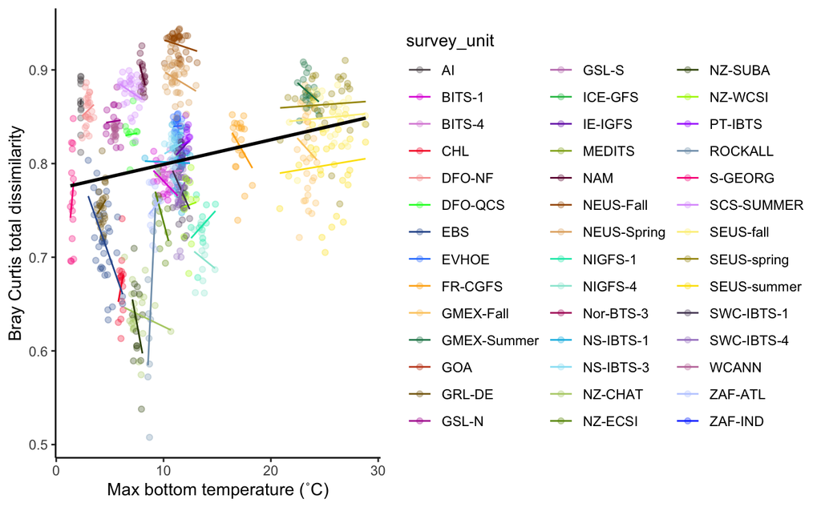

```r
dissimilarity_BC_total_sbt_max_facet <- ggplot(data = dissimilarities_temp) +
  labs(x = "Max bottom temperature (˚C)",  y = "Bray Curtis total dissimilarity") +
  geom_point(aes(x = yearly_max_bypoint_avg, y = bray_curtis_dissimilarity_total_mean), alpha = 0.3) +
  geom_smooth(aes(x = yearly_max_bypoint_avg, y = bray_curtis_dissimilarity_total_mean), method = "lm") +
  facet_wrap(~survey_unit, scales = "free") +
  theme_classic()

ggsave(dissimilarity_BC_total_sbt_max_facet, path  = here::here("figures","distance_decay"), filename = "dissimilarity_BC_total_sbt_max_facet.jpg", height = 10, width = 11, unit = "in")
```

```r
dissimilarity_BC_total_sbt_max_mod <- lm(bray_curtis_dissimilarity_total_mean ~ yearly_max_bypoint_avg, data = dissimilarities_temp) #this converges (allows both intercept and slope to vary with survey_unit)

summary(dissimilarity_BC_total_sbt_max_mod) #insignificant relationship
```

```
Call:
lm(formula = bray_curtis_dissimilarity_total_mean ~ yearly_max_bypoint_avg,
    data = dissimilarities_temp)

Residuals:
      Min        1Q    Median        3Q       Max
-0.287902 -0.043113  0.005702  0.049374  0.140874

Coefficients:
                        Estimate Std. Error t value Pr(>|t|)
(Intercept)            0.7727474  0.0054635 141.438  < 2e-16 ***
yearly_max_bypoint_avg 0.0026302  0.0003963   6.637 6.14e-11 ***
---
Signif. codes:  0 ‘***’ 0.001 ‘**’ 0.01 ‘*’ 0.05 ‘.’ 0.1 ‘ ’ 1

Residual standard error: 0.07545 on 751 degrees of freedom
  (144 observations deleted due to missingness)
Multiple R-squared:  0.0554,    Adjusted R-squared:  0.05415
F-statistic: 44.05 on 1 and 751 DF,  p-value: 6.136e-11
```

```r
confint <- confint(dissimilarity_BC_total_sbt_max_mod) #confidence interval

coefs <- data.frame(coef(summary(dissimilarity_BC_total_sbt_max_mod))) #table with coefficients, #Satterthwaite's degrees of freedom, and p-value approximation for fixed effects

#input results into table
total_dissimilarity_sbt_model_results_row <- data.table(matrix(c("sbt", #depth
                                                 F, #scaled
                                                 "yearly_max_bypoint_avg", #model structure
                                                 paste0(round(coef(dissimilarity_BC_total_sbt_max_mod)[[1]],3),
                                                        " ± ",
                                                        round((confint[1,2]-confint[1,1])/2,3)), #intercept
                                                 paste0(round(coef(dissimilarity_BC_total_sbt_max_mod)[[2]],3),
                                                        " ± ",
                                                        round((confint[2,2]-confint[2,1])/2,3)), #coef
                                                 round(coefs[2,4],3), #pvalue
                                                 round(summary(dissimilarity_BC_total_sbt_max_mod)$r.squared,3),#rsquared
                                                 round(AICc(dissimilarity_BC_total_sbt_max_mod),3)
                                                 ),nrow = 1))

#merge with larger table
total_dissimilarity_sbt_model_results <- rbind(total_dissimilarity_sbt_model_results,total_dissimilarity_sbt_model_results_row, use.names = F)

#########################
#max TEMP PLUS SURVEY UNIT
#########################
dissimilarity_BC_total_sbt_max_plus_survey_mod <- lm(bray_curtis_dissimilarity_total_mean ~ yearly_max_bypoint_avg + survey_unit, data = dissimilarities_temp) #this converges (allows both intercept and slope to vary with survey_unit)

summary(dissimilarity_BC_total_sbt_max_plus_survey_mod) #insignificant relationship
```

```
Call:
lm(formula = bray_curtis_dissimilarity_total_mean ~ yearly_max_bypoint_avg +
    survey_unit, data = dissimilarities_temp)

Residuals:
      Min        1Q    Median        3Q       Max
-0.128203 -0.013507  0.001898  0.014014  0.130769

Coefficients:
                        Estimate Std. Error t value Pr(>|t|)
(Intercept)             0.870021   0.008390 103.695  < 2e-16 ***
yearly_max_bypoint_avg -0.002009   0.001389  -1.446  0.14849
survey_unitBITS-1      -0.068556   0.014696  -4.665 3.68e-06 ***
survey_unitBITS-4      -0.057019   0.015402  -3.702  0.00023 ***
survey_unitCHL         -0.187791   0.011698 -16.054  < 2e-16 ***
survey_unitDFO-NF      -0.007565   0.009685  -0.781  0.43501
survey_unitDFO-QCS     -0.024651   0.013491  -1.827  0.06809 .
survey_unitEBS         -0.144356   0.009555 -15.109  < 2e-16 ***
survey_unitEVHOE       -0.007448   0.015844  -0.470  0.63842
survey_unitFR-CGFS     -0.016265   0.022746  -0.715  0.47480
survey_unitGMEX-Fall   -0.007919   0.030753  -0.257  0.79687
survey_unitGMEX-Summer  0.053461   0.031010   1.724  0.08514 .
survey_unitGRL-DE      -0.106621   0.010102 -10.555  < 2e-16 ***
survey_unitGSL-N       -0.014298   0.011586  -1.234  0.21758
survey_unitIE-IGFS     -0.031211   0.016920  -1.845  0.06551 .
survey_unitNAM          0.039643   0.013176   3.009  0.00272 **
survey_unitNEUS-Fall    0.079755   0.015412   5.175 2.97e-07 ***
survey_unitNEUS-Spring  0.042681   0.015270   2.795  0.00533 **
survey_unitNIGFS-1     -0.109361   0.019283  -5.671 2.05e-08 ***
survey_unitNIGFS-4     -0.143813   0.019505  -7.373 4.61e-13 ***
survey_unitNS-IBTS-1   -0.046106   0.015579  -2.960  0.00318 **
survey_unitNS-IBTS-3   -0.030942   0.015580  -1.986  0.04742 *
survey_unitNZ-CHAT     -0.215528   0.012221 -17.635  < 2e-16 ***
survey_unitNZ-ECSI     -0.104418   0.015315  -6.818 1.96e-11 ***
survey_unitNZ-SUBA     -0.225834   0.012861 -17.560  < 2e-16 ***
survey_unitNZ-WCSI     -0.089790   0.017878  -5.022 6.45e-07 ***
survey_unitPT-IBTS     -0.023257   0.017547  -1.325  0.18546
survey_unitROCKALL     -0.216651   0.015108 -14.340  < 2e-16 ***
survey_unitS-GEORG     -0.102903   0.010667  -9.647  < 2e-16 ***
survey_unitSCS-SUMMER   0.020608   0.011264   1.829  0.06774 .
survey_unitSEUS-fall    0.031328   0.033901   0.924  0.35576
survey_unitSEUS-spring  0.043596   0.033112   1.317  0.18839
survey_unitSEUS-summer -0.020697   0.033328  -0.621  0.53479
survey_unitSWC-IBTS-1  -0.076721   0.016230  -4.727 2.74e-06 ***
survey_unitSWC-IBTS-4  -0.080675   0.016352  -4.934 1.00e-06 ***
survey_unitWCANN       -0.024069   0.011346  -2.121  0.03424 *
survey_unitZAF-ATL     -0.098134   0.014069  -6.975 6.97e-12 ***
---
Signif. codes:  0 ‘***’ 0.001 ‘**’ 0.01 ‘*’ 0.05 ‘.’ 0.1 ‘ ’ 1

Residual standard error: 0.028 on 716 degrees of freedom
  (144 observations deleted due to missingness)
Multiple R-squared:  0.876, Adjusted R-squared:  0.8697
F-statistic: 140.5 on 36 and 716 DF,  p-value: < 2.2e-16
```

```r
confint <- confint(dissimilarity_BC_total_sbt_max_plus_survey_mod) #confidence interval

coefs <- data.frame(coef(summary(dissimilarity_BC_total_sbt_max_plus_survey_mod))) #table with coefficients, #Satterthwaite's degrees of freedom, and p-value approximation for fixed effects

#input results into table
total_dissimilarity_sbt_model_results_row <- data.table(matrix(c("sbt", #depth
                                                 F, #scaled
                                                 "yearly_max_bypoint_avg + survey_unit", #model structure
                                                 paste0(round(coef(dissimilarity_BC_total_sbt_max_plus_survey_mod)[[1]],3),
                                                        " ± ",
                                                        round((confint[1,2]-confint[1,1])/2,3)), #intercept
                                                 paste0(round(coef(dissimilarity_BC_total_sbt_max_plus_survey_mod)[[2]],3),
                                                        " ± ",
                                                        round((confint[2,2]-confint[2,1])/2,3)), #coef
                                                 overall_p(dissimilarity_BC_total_sbt_max_plus_survey_mod), #model pvalue
                                                 round(summary(dissimilarity_BC_total_sbt_max_plus_survey_mod)$r.squared,3),#rsquared
                                                 round(AICc(dissimilarity_BC_total_sbt_max_plus_survey_mod),3)
                                                 ),nrow = 1))

#merge with larger table
total_dissimilarity_sbt_model_results <- rbind(total_dissimilarity_sbt_model_results,total_dissimilarity_sbt_model_results_row, use.names = F)

#########################
#max TEMP * SURVEY UNIT
#########################
dissimilarity_BC_total_sbt_max_times_survey_mod <- lm(bray_curtis_dissimilarity_total_mean ~ yearly_max_bypoint_avg * survey_unit, data = dissimilarities_temp) #this converges (allows both intercept and slope to vary with survey_unit)

summary(dissimilarity_BC_total_sbt_max_times_survey_mod) #insignificant relationship
```

```
Call:
lm(formula = bray_curtis_dissimilarity_total_mean ~ yearly_max_bypoint_avg *
    survey_unit, data = dissimilarities_temp)

Residuals:
      Min        1Q    Median        3Q       Max
-0.111683 -0.012357  0.001806  0.014089  0.089916

Coefficients:
                                               Estimate Std. Error t value Pr(>|t|)
(Intercept)                                    0.614533   1.087969   0.565   0.5724
yearly_max_bypoint_avg                         0.109736   0.475845   0.231   0.8177
survey_unitBITS-1                              0.285713   1.093491   0.261   0.7940
survey_unitBITS-4                              0.167401   1.094942   0.153   0.8785
survey_unitCHL                                -0.328583   1.142179  -0.288   0.7737
survey_unitDFO-NF                              0.208738   1.090364   0.191   0.8482
survey_unitDFO-QCS                             0.200691   1.100902   0.182   0.8554
survey_unitEBS                                 0.248241   1.088345   0.228   0.8196
survey_unitEVHOE                               0.215852   1.148001   0.188   0.8509
survey_unitFR-CGFS                             0.547721   1.111818   0.493   0.6224
survey_unitGMEX-Fall                           0.498926   1.117964   0.446   0.6555
survey_unitGMEX-Summer                         0.499385   1.121433   0.445   0.6562
survey_unitGRL-DE                              0.058170   1.093417   0.053   0.9576
survey_unitGSL-N                               0.220327   1.091077   0.202   0.8400
survey_unitIE-IGFS                             0.054329   1.131971   0.048   0.9617
survey_unitNAM                                 0.631161   1.144316   0.552   0.5814
survey_unitNEUS-Fall                           0.355855   1.091261   0.326   0.7445
survey_unitNEUS-Spring                         0.353154   1.090792   0.324   0.7462
survey_unitNIGFS-1                            -0.054910   1.105706  -0.050   0.9604
survey_unitNIGFS-4                             0.210481   1.111590   0.189   0.8499
survey_unitNS-IBTS-1                           0.192343   1.090741   0.176   0.8601
survey_unitNS-IBTS-3                           0.123779   1.104125   0.112   0.9108
survey_unitNZ-CHAT                             0.066817   1.089083   0.061   0.9511
survey_unitNZ-ECSI                             0.550695   1.103860   0.499   0.6180
survey_unitNZ-SUBA                             0.478972   1.105023   0.433   0.6648
survey_unitNZ-WCSI                             0.087558   1.125506   0.078   0.9380
survey_unitPT-IBTS                             0.126746   1.161975   0.109   0.9132
survey_unitROCKALL                            -2.118942   1.144425  -1.852   0.0645 .
survey_unitS-GEORG                            -0.038447   1.094282  -0.035   0.9720
survey_unitSCS-SUMMER                          0.316414   1.089501   0.290   0.7716
```

[output cut: 34 more lines]

```
yearly_max_bypoint_avg:survey_unitSCS-SUMMER  -0.117542   0.475917  -0.247   0.8050
yearly_max_bypoint_avg:survey_unitSEUS-fall   -0.108600   0.475856  -0.228   0.8195
yearly_max_bypoint_avg:survey_unitSEUS-spring -0.108895   0.475853  -0.229   0.8191
yearly_max_bypoint_avg:survey_unitSEUS-summer -0.107806   0.475853  -0.227   0.8208
yearly_max_bypoint_avg:survey_unitSWC-IBTS-1  -0.135689   0.476133  -0.285   0.7757
yearly_max_bypoint_avg:survey_unitSWC-IBTS-4  -0.075742   0.476669  -0.159   0.8738
yearly_max_bypoint_avg:survey_unitWCANN       -0.109848   0.483020  -0.227   0.8202
yearly_max_bypoint_avg:survey_unitZAF-ATL     -0.095196   0.476388  -0.200   0.8417
---
Signif. codes:  0 ‘***’ 0.001 ‘**’ 0.01 ‘*’ 0.05 ‘.’ 0.1 ‘ ’ 1

Residual standard error: 0.02694 on 681 degrees of freedom
  (144 observations deleted due to missingness)
Multiple R-squared:  0.8908,    Adjusted R-squared:  0.8794
F-statistic: 78.22 on 71 and 681 DF,  p-value: < 2.2e-16
```

```r
confint <- confint(dissimilarity_BC_total_sbt_max_times_survey_mod) #confidence interval

coefs <- data.frame(coef(summary(dissimilarity_BC_total_sbt_max_times_survey_mod))) #table with coefficients, #Satterthwaite's degrees of freedom, and p-value approximation for fixed effects

#input results into table
total_dissimilarity_sbt_model_results_row <- data.table(matrix(c("sbt", #depth
                                                 F, #scaled
                                                 "yearly_max_bypoint_avg * survey_unit", #model structure
                                                 paste0(round(coef(dissimilarity_BC_total_sbt_max_times_survey_mod)[[1]],3),
                                                        " ± ",
                                                        round((confint[1,2]-confint[1,1])/2,3)), #intercept
                                                 paste0(round(coef(dissimilarity_BC_total_sbt_max_times_survey_mod)[[2]],3),
                                                        " ± ",
                                                        round((confint[2,2]-confint[2,1])/2,3)), #coef
                                                 signif(overall_p(dissimilarity_BC_total_sbt_max_times_survey_mod),2), #model pvalue
                                                 round(summary(dissimilarity_BC_total_sbt_max_times_survey_mod)$r.squared,3),#rsquared
                                                 round(AICc(dissimilarity_BC_total_sbt_max_times_survey_mod),3)
                                                 ),nrow = 1))

#merge with larger table
total_dissimilarity_sbt_model_results <- rbind(total_dissimilarity_sbt_model_results,total_dissimilarity_sbt_model_results_row, use.names = F)
```

####Seas sbt

```r
#for all regions
(dissimilarity_BC_total_sbt_seas <- ggplot(data = dissimilarities_temp) +
  labs(x = "Seasonality of bottom temperature (˚C)",  y = "Bray Curtis total dissimilarity") +
  geom_point(aes(x = yearly_seas_bypoint_avg, y = bray_curtis_dissimilarity_total_mean, color = survey_unit), alpha = 0.3) +
  geom_line(aes(x = yearly_seas_bypoint_avg, y = bray_curtis_dissimilarity_total_mean, color = survey_unit), stat="smooth", method = "lm") +
  scale_color_manual(values = c(palette_42)) +
  geom_smooth(aes(x = yearly_seas_bypoint_avg, y = bray_curtis_dissimilarity_total_mean), method = "lm", se = F, color  = "black") +
  theme_classic())

ggsave(dissimilarity_BC_total_sbt_seas, path  = here::here("figures","distance_decay"), filename = "dissimilarity_BC_total_sbt_seas.jpg", height = 4, width = 9, unit = "in")
```

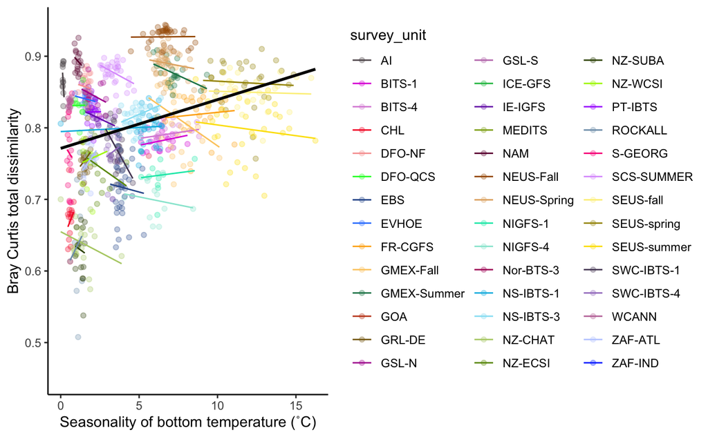

```r
dissimilarity_BC_total_sbt_seas_facet <- ggplot(data = dissimilarities_temp) +
  labs(x = "Seasonality of bottom temperature (˚C)",  y = "Bray Curtis total dissimilarity") +
  geom_point(aes(x = yearly_seas_bypoint_avg, y = bray_curtis_dissimilarity_total_mean), alpha = 0.3) +
  geom_smooth(aes(x = yearly_seas_bypoint_avg, y = bray_curtis_dissimilarity_total_mean), method = "lm") +
  facet_wrap(~survey_unit, scales = "free") +
  theme_classic()

ggsave(dissimilarity_BC_total_sbt_seas_facet, path  = here::here("figures","distance_decay"), filename = "dissimilarity_BC_total_sbt_seas_facet.jpg", height = 10, width = 11, unit = "in")
```

```r
dissimilarity_BC_total_sbt_seas_mod <- lm(bray_curtis_dissimilarity_total_mean ~ yearly_seas_bypoint_avg, data = dissimilarities_temp) #this converges (allows both intercept and slope to vary with survey_unit)

summary(dissimilarity_BC_total_sbt_seas_mod) #insignificant relationship
```

```
Call:
lm(formula = bray_curtis_dissimilarity_total_mean ~ yearly_seas_bypoint_avg,
    data = dissimilarities_temp)

Residuals:
     Min       1Q   Median       3Q      Max
-0.27115 -0.04319  0.00178  0.05789  0.14669

Coefficients:
                         Estimate Std. Error t value Pr(>|t|)
(Intercept)             0.7712799  0.0045118 170.946   <2e-16 ***
yearly_seas_bypoint_avg 0.0068108  0.0007527   9.049   <2e-16 ***
---
Signif. codes:  0 ‘***’ 0.001 ‘**’ 0.01 ‘*’ 0.05 ‘.’ 0.1 ‘ ’ 1

Residual standard error: 0.07372 on 751 degrees of freedom
  (144 observations deleted due to missingness)
Multiple R-squared:  0.09831,   Adjusted R-squared:  0.09711
F-statistic: 81.88 on 1 and 751 DF,  p-value: < 2.2e-16
```

```r
confint <- confint(dissimilarity_BC_total_sbt_seas_mod) #confidence interval

coefs <- data.frame(coef(summary(dissimilarity_BC_total_sbt_seas_mod))) #table with coefficients, #Satterthwaite's degrees of freedom, and p-value approximation for fixed effects

#input results into table
total_dissimilarity_sbt_model_results_row <- data.table(matrix(c("sbt", #depth
                                                 F, #scaled
                                                 "yearly_seas_bypoint_avg", #model structure
                                                 paste0(round(coef(dissimilarity_BC_total_sbt_seas_mod)[[1]],3),
                                                        " ± ",
                                                        round((confint[1,2]-confint[1,1])/2,3)), #intercept
                                                 paste0(round(coef(dissimilarity_BC_total_sbt_seas_mod)[[2]],3),
                                                        " ± ",
                                                        round((confint[2,2]-confint[2,1])/2,3)), #coef
                                                 round(coefs[2,4],3), #pvalue
                                                 round(summary(dissimilarity_BC_total_sbt_seas_mod)$r.squared,3),#rsquared
                                                 round(AICc(dissimilarity_BC_total_sbt_seas_mod),3)
                                                 ),nrow = 1))

#merge with larger table
total_dissimilarity_sbt_model_results <- rbind(total_dissimilarity_sbt_model_results,total_dissimilarity_sbt_model_results_row, use.names = F)

#########################
#seas TEMP PLUS SURVEY UNIT
#########################
dissimilarity_BC_total_sbt_seas_plus_survey_mod <- lm(bray_curtis_dissimilarity_total_mean ~ yearly_seas_bypoint_avg + survey_unit, data = dissimilarities_temp) #this converges (allows both intercept and slope to vary with survey_unit)

summary(dissimilarity_BC_total_sbt_seas_plus_survey_mod) #insignificant relationship
```

```
Call:
lm(formula = bray_curtis_dissimilarity_total_mean ~ yearly_seas_bypoint_avg +
    survey_unit, data = dissimilarities_temp)

Residuals:
      Min        1Q    Median        3Q       Max
-0.127945 -0.013497  0.001887  0.014371  0.130211

Coefficients:
                         Estimate Std. Error t value Pr(>|t|)
(Intercept)              0.865811   0.007758 111.602  < 2e-16 ***
yearly_seas_bypoint_avg -0.002526   0.001269  -1.991 0.046834 *
survey_unitBITS-1       -0.068510   0.012729  -5.382 9.98e-08 ***
survey_unitBITS-4       -0.056712   0.013248  -4.281 2.12e-05 ***
survey_unitCHL          -0.194224   0.010457 -18.573  < 2e-16 ***
survey_unitDFO-NF       -0.005058   0.009820  -0.515 0.606675
survey_unitDFO-QCS      -0.031578   0.011834  -2.668 0.007793 **
survey_unitEBS          -0.139183   0.010243 -13.588  < 2e-16 ***
survey_unitEVHOE        -0.021651   0.009968  -2.172 0.030178 *
survey_unitFR-CGFS      -0.023478   0.014939  -1.572 0.116481
survey_unitGMEX-Fall    -0.032137   0.012975  -2.477 0.013481 *
survey_unitGMEX-Summer   0.028685   0.013295   2.158 0.031296 *
survey_unitGRL-DE       -0.107138   0.009859 -10.867  < 2e-16 ***
survey_unitGSL-N        -0.015502   0.011050  -1.403 0.161095
survey_unitIE-IGFS      -0.044784   0.011093  -4.037 5.99e-05 ***
survey_unitNAM           0.030399   0.010508   2.893 0.003933 **
survey_unitNEUS-Fall     0.078133   0.012227   6.390 2.99e-10 ***
survey_unitNEUS-Spring   0.041461   0.012266   3.380 0.000763 ***
survey_unitNIGFS-1      -0.116820   0.013560  -8.615  < 2e-16 ***
survey_unitNIGFS-4      -0.151719   0.013686 -11.085  < 2e-16 ***
survey_unitNS-IBTS-1    -0.051084   0.011247  -4.542 6.54e-06 ***
survey_unitNS-IBTS-3    -0.036690   0.011431  -3.210 0.001389 **
survey_unitNZ-CHAT      -0.223190   0.009824 -22.719  < 2e-16 ***
survey_unitNZ-ECSI      -0.113711   0.011567  -9.830  < 2e-16 ***
survey_unitNZ-SUBA      -0.233488   0.010693 -21.835  < 2e-16 ***
survey_unitNZ-WCSI      -0.105827   0.011383  -9.297  < 2e-16 ***
survey_unitPT-IBTS      -0.038176   0.011238  -3.397 0.000719 ***
survey_unitROCKALL      -0.227354   0.012181 -18.665  < 2e-16 ***
survey_unitS-GEORG      -0.100286   0.010609  -9.453  < 2e-16 ***
survey_unitSCS-SUMMER    0.019473   0.010087   1.931 0.053935 .
survey_unitSEUS-fall     0.014552   0.017895   0.813 0.416378
survey_unitSEUS-spring   0.026811   0.017367   1.544 0.123077
survey_unitSEUS-summer  -0.037441   0.017506  -2.139 0.032789 *
survey_unitSWC-IBTS-1   -0.087013   0.010505  -8.283 5.91e-16 ***
survey_unitSWC-IBTS-4   -0.091336   0.010831  -8.433  < 2e-16 ***
survey_unitWCANN        -0.029356   0.010456  -2.808 0.005126 **
survey_unitZAF-ATL      -0.107799   0.010514 -10.253  < 2e-16 ***
---
Signif. codes:  0 ‘***’ 0.001 ‘**’ 0.01 ‘*’ 0.05 ‘.’ 0.1 ‘ ’ 1

Residual standard error: 0.02796 on 716 degrees of freedom
  (144 observations deleted due to missingness)
Multiple R-squared:  0.8763,    Adjusted R-squared:  0.8701
F-statistic: 140.9 on 36 and 716 DF,  p-value: < 2.2e-16
```

```r
confint <- confint(dissimilarity_BC_total_sbt_seas_plus_survey_mod) #confidence interval

coefs <- data.frame(coef(summary(dissimilarity_BC_total_sbt_seas_plus_survey_mod))) #table with coefficients, #Satterthwaite's degrees of freedom, and p-value approximation for fixed effects

#input results into table
total_dissimilarity_sbt_model_results_row <- data.table(matrix(c("sbt", #depth
                                                 F, #scaled
                                                 "yearly_seas_bypoint_avg + survey_unit", #model structure
                                                 paste0(round(coef(dissimilarity_BC_total_sbt_seas_plus_survey_mod)[[1]],3),
                                                        " ± ",
                                                        round((confint[1,2]-confint[1,1])/2,3)), #intercept
                                                 paste0(round(coef(dissimilarity_BC_total_sbt_seas_plus_survey_mod)[[2]],3),
                                                        " ± ",
                                                        round((confint[2,2]-confint[2,1])/2,3)), #coef
                                                 overall_p(dissimilarity_BC_total_sbt_seas_plus_survey_mod), #model pvalue
                                                 round(summary(dissimilarity_BC_total_sbt_seas_plus_survey_mod)$r.squared,3),#rsquared
                                                 round(AICc(dissimilarity_BC_total_sbt_seas_plus_survey_mod),3)
                                                 ),nrow = 1))

#merge with larger table
total_dissimilarity_sbt_model_results <- rbind(total_dissimilarity_sbt_model_results,total_dissimilarity_sbt_model_results_row, use.names = F)

#########################
#seas TEMP * SURVEY UNIT
#########################
dissimilarity_BC_total_sbt_seas_times_survey_mod <- lm(bray_curtis_dissimilarity_total_mean ~ yearly_seas_bypoint_avg * survey_unit, data = dissimilarities_temp) #this converges (allows both intercept and slope to vary with survey_unit)

summary(dissimilarity_BC_total_sbt_seas_times_survey_mod) #insignificant relationship
```

```
Call:
lm(formula = bray_curtis_dissimilarity_total_mean ~ yearly_seas_bypoint_avg *
    survey_unit, data = dissimilarities_temp)

Residuals:
      Min        1Q    Median        3Q       Max
-0.130248 -0.012735  0.002182  0.013652  0.122609

Coefficients:
                                                Estimate Std. Error t value Pr(>|t|)
(Intercept)                                     0.921625   0.045564  20.227  < 2e-16 ***
yearly_seas_bypoint_avg                        -0.369676   0.295310  -1.252 0.211063
survey_unitBITS-1                              -0.168602   0.072143  -2.337 0.019725 *
survey_unitBITS-4                              -0.152894   0.066935  -2.284 0.022665 *
survey_unitCHL                                 -0.285668   0.063384  -4.507 7.74e-06 ***
survey_unitDFO-NF                              -0.052941   0.070073  -0.756 0.450199
survey_unitDFO-QCS                             -0.091288   0.062719  -1.456 0.145990
survey_unitEBS                                 -0.181367   0.060838  -2.981 0.002974 **
survey_unitEVHOE                               -0.071970   0.062042  -1.160 0.246442
survey_unitFR-CGFS                             -0.122600   0.067986  -1.803 0.071781 .
survey_unitGMEX-Fall                            0.006087   0.060281   0.101 0.919600
survey_unitGMEX-Summer                          0.027198   0.072110   0.377 0.706159
survey_unitGRL-DE                              -0.212626   0.068581  -3.100 0.002013 **
survey_unitGSL-N                               -0.051762   0.055959  -0.925 0.355297
survey_unitIE-IGFS                             -0.082715   0.060521  -1.367 0.172169
survey_unitNAM                                 -0.000983   0.075412  -0.013 0.989604
survey_unitNEUS-Fall                            0.004307   0.059639   0.072 0.942450
survey_unitNEUS-Spring                         -0.002728   0.066679  -0.041 0.967374
survey_unitNIGFS-1                             -0.205914   0.075731  -2.719 0.006714 **
survey_unitNIGFS-4                             -0.195942   0.068967  -2.841 0.004630 **
survey_unitNS-IBTS-1                           -0.126901   0.051801  -2.450 0.014545 *
survey_unitNS-IBTS-3                           -0.150157   0.066027  -2.274 0.023266 *
survey_unitNZ-CHAT                             -0.266775   0.047288  -5.642 2.47e-08 ***
survey_unitNZ-ECSI                             -0.137783   0.055558  -2.480 0.013380 *
survey_unitNZ-SUBA                             -0.272039   0.065907  -4.128 4.12e-05 ***
survey_unitNZ-WCSI                             -0.183595   0.057646  -3.185 0.001514 **
survey_unitPT-IBTS                             -0.099305   0.088241  -1.125 0.260826
survey_unitROCKALL                             -0.333535   0.066578  -5.010 6.96e-07 ***
survey_unitS-GEORG                             -0.137059   0.065287  -2.099 0.036155 *
survey_unitSCS-SUMMER                          -0.004054   0.056343  -0.072 0.942666
```

[output cut: 34 more lines]

```
yearly_seas_bypoint_avg:survey_unitSCS-SUMMER   0.357701   0.295465   1.211 0.226454
yearly_seas_bypoint_avg:survey_unitSEUS-fall    0.369051   0.295328   1.250 0.211864
yearly_seas_bypoint_avg:survey_unitSEUS-spring  0.368457   0.295328   1.248 0.212600
yearly_seas_bypoint_avg:survey_unitSEUS-summer  0.366670   0.295324   1.242 0.214817
yearly_seas_bypoint_avg:survey_unitSWC-IBTS-1   0.329734   0.295760   1.115 0.265298
yearly_seas_bypoint_avg:survey_unitSWC-IBTS-4   0.387160   0.296445   1.306 0.191990
yearly_seas_bypoint_avg:survey_unitWCANN        0.400010   0.314293   1.273 0.203548
yearly_seas_bypoint_avg:survey_unitZAF-ATL      0.401489   0.296412   1.354 0.176028
---
Signif. codes:  0 ‘***’ 0.001 ‘**’ 0.01 ‘*’ 0.05 ‘.’ 0.1 ‘ ’ 1

Residual standard error: 0.02808 on 681 degrees of freedom
  (144 observations deleted due to missingness)
Multiple R-squared:  0.8814,    Adjusted R-squared:  0.869
F-statistic: 71.25 on 71 and 681 DF,  p-value: < 2.2e-16
```

```r
confint <- confint(dissimilarity_BC_total_sbt_seas_times_survey_mod) #confidence interval

coefs <- data.frame(coef(summary(dissimilarity_BC_total_sbt_seas_times_survey_mod))) #table with coefficients, #Satterthwaite's degrees of freedom, and p-value approximation for fixed effects

#input results into table
total_dissimilarity_sbt_model_results_row <- data.table(matrix(c("sbt", #depth
                                                 F, #scaled
                                                 "yearly_seas_bypoint_avg * survey_unit", #model structure
                                                 paste0(round(coef(dissimilarity_BC_total_sbt_seas_times_survey_mod)[[1]],3),
                                                        " ± ",
                                                        round((confint[1,2]-confint[1,1])/2,3)), #intercept
                                                 paste0(round(coef(dissimilarity_BC_total_sbt_seas_times_survey_mod)[[2]],3),
                                                        " ± ",
                                                        round((confint[2,2]-confint[2,1])/2,3)), #coef
                                                 signif(overall_p(dissimilarity_BC_total_sbt_seas_times_survey_mod),2), #model pvalue
                                                 round(summary(dissimilarity_BC_total_sbt_seas_times_survey_mod)$r.squared,3),#rsquared
                                                 round(AICc(dissimilarity_BC_total_sbt_seas_times_survey_mod),3)
                                                 ),nrow = 1))

#merge with larger table
total_dissimilarity_sbt_model_results <- rbind(total_dissimilarity_sbt_model_results,total_dissimilarity_sbt_model_results_row, use.names = F)
```

SD of mean

```r
#for all regions
(dissimilarity_BC_total_sbt_meanSD <- ggplot(data = dissimilarities_temp) +
  labs(x = "SD ",  y = "Bray Curtis total dissimilarity") +
  geom_point(aes(x = yearly_mean_bypoint_SD, y = bray_curtis_dissimilarity_total_mean, color = survey_unit), alpha = 0.3) +
  geom_line(aes(x = yearly_mean_bypoint_SD, y = bray_curtis_dissimilarity_total_mean, color = survey_unit), stat="smooth", method = "lm") +
  scale_color_manual(values = c(palette_42)) +
  geom_smooth(aes(x = yearly_mean_bypoint_SD, y = bray_curtis_dissimilarity_total_mean), method = "lm", se = F, color  = "black") +
  theme_classic())

ggsave(dissimilarity_BC_total_sbt_meanSD, path  = here::here("figures","distance_decay"), filename = "dissimilarity_BC_total_sbt_meanSD.jpg", height = 4, width = 9, unit = "in")
```

[figure not shown]

```r
dissimilarity_BC_total_sbt_meanSD_facet <- ggplot(data = dissimilarities_temp) +
  labs(x = "SD of mean bottom temperature",  y = "Bray Curtis total dissimilarity") +
  geom_point(aes(x = yearly_mean_bypoint_SD, y = bray_curtis_dissimilarity_total_mean), alpha = 0.3) +
  geom_smooth(aes(x = yearly_mean_bypoint_SD, y = bray_curtis_dissimilarity_total_mean), method = "lm") +
  facet_wrap(~survey_unit, scales = "free") +
  theme_classic()

ggsave(dissimilarity_BC_total_sbt_meanSD_facet, path  = here::here("figures","distance_decay"), filename = "dissimilarity_BC_total_sbt_meanSD_facet.jpg", height = 10, width = 11, unit = "in")
```

```r
dissimilarity_BC_total_sbt_meanSD_mod <- lm(bray_curtis_dissimilarity_total_mean ~ yearly_mean_bypoint_SD, data = dissimilarities_temp) #this converges (allows both intercept and slope to vary with survey_unit)

summary(dissimilarity_BC_total_sbt_meanSD_mod) #insignificant relationship
```

```
Call:
lm(formula = bray_curtis_dissimilarity_total_mean ~ yearly_mean_bypoint_SD,
    data = dissimilarities_temp)

Residuals:
     Min       1Q   Median       3Q      Max
-0.28987 -0.03762  0.01304  0.05489  0.12706

Coefficients:
                       Estimate Std. Error t value Pr(>|t|)
(Intercept)            0.762237   0.005900 129.195  < 2e-16 ***
yearly_mean_bypoint_SD 0.021134   0.002645   7.989  5.1e-15 ***
---
Signif. codes:  0 ‘***’ 0.001 ‘**’ 0.01 ‘*’ 0.05 ‘.’ 0.1 ‘ ’ 1

Residual standard error: 0.07453 on 751 degrees of freedom
  (144 observations deleted due to missingness)
Multiple R-squared:  0.07834,   Adjusted R-squared:  0.07711
F-statistic: 63.83 on 1 and 751 DF,  p-value: 5.1e-15
```

```r
confint <- confint(dissimilarity_BC_total_sbt_meanSD_mod) #confidence interval

coefs <- data.frame(coef(summary(dissimilarity_BC_total_sbt_meanSD_mod))) #table with coefficients, #Satterthwaite's degrees of freedom, and p-value approximation for fixed effects

#input results into table
total_dissimilarity_sbt_model_results_row <- data.table(matrix(c("sbt", #depth
                                                 F, #scaled
                                                 "yearly_mean_bypoint_SD", #model structure
                                                 paste0(round(coef(dissimilarity_BC_total_sbt_meanSD_mod)[[1]],3),
                                                        " ± ",
                                                        round((confint[1,2]-confint[1,1])/2,3)), #intercept
                                                 paste0(round(coef(dissimilarity_BC_total_sbt_meanSD_mod)[[2]],3),
                                                        " ± ",
                                                        round((confint[2,2]-confint[2,1])/2,3)), #coef
                                                 round(coefs[2,4],3), #pvalue
                                                 round(summary(dissimilarity_BC_total_sbt_meanSD_mod)$r.squared,3),#rsquared
                                                 round(AICc(dissimilarity_BC_total_sbt_meanSD_mod),3)
                                                 ),nrow = 1))

#merge with larger table
total_dissimilarity_sbt_model_results <- rbind(total_dissimilarity_sbt_model_results,total_dissimilarity_sbt_model_results_row, use.names = F)

#########################
#SD TEMP PLUS SURVEY UNIT
#########################
dissimilarity_BC_total_sbt_meanSD_plus_survey_mod <- lm(bray_curtis_dissimilarity_total_mean ~ yearly_mean_bypoint_SD + survey_unit, data = dissimilarities_temp) #this converges (allows both intercept and slope to vary with survey_unit)

summary(dissimilarity_BC_total_sbt_meanSD_plus_survey_mod) #insignificant relationship
```

```
Call:
lm(formula = bray_curtis_dissimilarity_total_mean ~ yearly_mean_bypoint_SD +
    survey_unit, data = dissimilarities_temp)

Residuals:
      Min        1Q    Median        3Q       Max
-0.128325 -0.013293  0.002141  0.013594  0.130882

Coefficients:
                         Estimate Std. Error t value Pr(>|t|)
(Intercept)             0.8698565  0.0084695 102.704  < 2e-16 ***
yearly_mean_bypoint_SD -0.0054354  0.0041421  -1.312  0.18986
survey_unitBITS-1      -0.0789708  0.0107919  -7.318 6.79e-13 ***
survey_unitBITS-4      -0.0686441  0.0108376  -6.334 4.22e-10 ***
survey_unitCHL         -0.1808472  0.0152321 -11.873  < 2e-16 ***
survey_unitDFO-NF      -0.0044855  0.0102105  -0.439  0.66058
survey_unitDFO-QCS     -0.0301876  0.0121651  -2.481  0.01331 *
survey_unitEBS         -0.1463638  0.0092423 -15.836  < 2e-16 ***
survey_unitEVHOE       -0.0145583  0.0128465  -1.133  0.25749
survey_unitFR-CGFS     -0.0464392  0.0098044  -4.737 2.62e-06 ***
survey_unitGMEX-Fall   -0.0311335  0.0173073  -1.799  0.07246 .
survey_unitGMEX-Summer  0.0292676  0.0171076   1.711  0.08755 .
survey_unitGRL-DE      -0.1105758  0.0097182 -11.378  < 2e-16 ***
survey_unitGSL-N       -0.0149099  0.0115766  -1.288  0.19818
survey_unitIE-IGFS     -0.0479452  0.0109082  -4.395 1.27e-05 ***
survey_unitNAM          0.0410908  0.0144294   2.848  0.00453 **
survey_unitNEUS-Fall    0.0729567  0.0124623   5.854 7.30e-09 ***
survey_unitNEUS-Spring  0.0363778  0.0125840   2.891  0.00396 **
survey_unitNIGFS-1     -0.1327873  0.0112256 -11.829  < 2e-16 ***
survey_unitNIGFS-4     -0.1673956  0.0114885 -14.571  < 2e-16 ***
survey_unitNS-IBTS-1   -0.0616218  0.0092874  -6.635 6.40e-11 ***
survey_unitNS-IBTS-3   -0.0456281  0.0100336  -4.548 6.37e-06 ***
survey_unitNZ-CHAT     -0.2202836  0.0107300 -20.530  < 2e-16 ***
survey_unitNZ-ECSI     -0.1124646  0.0124319  -9.046  < 2e-16 ***
survey_unitNZ-SUBA     -0.2319130  0.0111376 -20.822  < 2e-16 ***
survey_unitNZ-WCSI     -0.1013263  0.0129906  -7.800 2.19e-14 ***
survey_unitPT-IBTS     -0.0280297  0.0158664  -1.767  0.07772 .
survey_unitROCKALL     -0.2247396  0.0127092 -17.683  < 2e-16 ***
survey_unitS-GEORG     -0.1032163  0.0107115  -9.636  < 2e-16 ***
survey_unitSCS-SUMMER   0.0193542  0.0111008   1.744  0.08167 .
survey_unitSEUS-fall   -0.0129087  0.0096523  -1.337  0.18152
survey_unitSEUS-spring  0.0007475  0.0096418   0.078  0.93823
survey_unitSEUS-summer -0.0640752  0.0095616  -6.701 4.18e-11 ***
survey_unitSWC-IBTS-1  -0.0943442  0.0096305  -9.796  < 2e-16 ***
survey_unitSWC-IBTS-4  -0.0945107  0.0107212  -8.815  < 2e-16 ***
survey_unitWCANN       -0.0214268  0.0125133  -1.712  0.08727 .
survey_unitZAF-ATL     -0.1021143  0.0127634  -8.001 4.99e-15 ***
---
Signif. codes:  0 ‘***’ 0.001 ‘**’ 0.01 ‘*’ 0.05 ‘.’ 0.1 ‘ ’ 1

Residual standard error: 0.02801 on 716 degrees of freedom
  (144 observations deleted due to missingness)
Multiple R-squared:  0.8759,    Adjusted R-squared:  0.8697
F-statistic: 140.4 on 36 and 716 DF,  p-value: < 2.2e-16
```

```r
confint <- confint(dissimilarity_BC_total_sbt_meanSD_plus_survey_mod) #confidence interval

coefs <- data.frame(coef(summary(dissimilarity_BC_total_sbt_meanSD_plus_survey_mod))) #table with coefficients, #Satterthwaite's degrees of freedom, and p-value approximation for fixed effects

#input results into table
total_dissimilarity_sbt_model_results_row <- data.table(matrix(c("sbt", #depth
                                                 F, #scaled
                                                 "yearly_mean_bypoint_SD + survey_unit", #model structure
                                                 paste0(round(coef(dissimilarity_BC_total_sbt_meanSD_plus_survey_mod)[[1]],3),
                                                        " ± ",
                                                        round((confint[1,2]-confint[1,1])/2,3)), #intercept
                                                 paste0(round(coef(dissimilarity_BC_total_sbt_meanSD_plus_survey_mod)[[2]],3),
                                                        " ± ",
                                                        round((confint[2,2]-confint[2,1])/2,3)), #coef
                                                 overall_p(dissimilarity_BC_total_sbt_meanSD_plus_survey_mod), #model pvalue
                                                 round(summary(dissimilarity_BC_total_sbt_meanSD_plus_survey_mod)$r.squared,3),#rsquared
                                                 round(AICc(dissimilarity_BC_total_sbt_meanSD_plus_survey_mod),3)
                                                 ),nrow = 1))

#merge with larger table
total_dissimilarity_sbt_model_results <- rbind(total_dissimilarity_sbt_model_results,total_dissimilarity_sbt_model_results_row, use.names = F)

#########################
#SD TEMP * SURVEY UNIT
#########################
dissimilarity_BC_total_sbt_meanSD_times_survey_mod <- lm(bray_curtis_dissimilarity_total_mean ~ yearly_mean_bypoint_SD * survey_unit, data = dissimilarities_temp) #this converges (allows both intercept and slope to vary with survey_unit)

summary(dissimilarity_BC_total_sbt_meanSD_times_survey_mod) #insignificant relationship
```

```
Call:
lm(formula = bray_curtis_dissimilarity_total_mean ~ yearly_mean_bypoint_SD *
    survey_unit, data = dissimilarities_temp)

Residuals:
      Min        1Q    Median        3Q       Max
-0.102563 -0.011889  0.001951  0.013748  0.094381

Coefficients:
                                              Estimate Std. Error t value Pr(>|t|)
(Intercept)                                    0.96661    0.25412   3.804 0.000155 ***
yearly_mean_bypoint_SD                        -0.12416    0.31168  -0.398 0.690493
survey_unitBITS-1                             -0.23255    0.25861  -0.899 0.368845
survey_unitBITS-4                             -0.17804    0.25771  -0.691 0.489905
survey_unitCHL                                -0.45720    0.34041  -1.343 0.179691
survey_unitDFO-NF                             -0.11098    0.26985  -0.411 0.681002
survey_unitDFO-QCS                            -0.12758    0.28792  -0.443 0.657829
survey_unitEBS                                -0.31952    0.25663  -1.245 0.213534
survey_unitEVHOE                              -0.13002    0.30084  -0.432 0.665733
survey_unitFR-CGFS                            -0.14441    0.25632  -0.563 0.573360
survey_unitGMEX-Fall                          -0.20836    0.26425  -0.788 0.430679
survey_unitGMEX-Summer                        -0.19313    0.27529  -0.702 0.483190
survey_unitGRL-DE                             -0.16868    0.25942  -0.650 0.515781
survey_unitGSL-N                              -0.20461    0.27213  -0.752 0.452379
survey_unitIE-IGFS                            -0.22644    0.27626  -0.820 0.412699
survey_unitNAM                                 0.13785    0.30721   0.449 0.653773
survey_unitNEUS-Fall                          -0.06874    0.25739  -0.267 0.789498
survey_unitNEUS-Spring                        -0.07752    0.25751  -0.301 0.763471
survey_unitNIGFS-1                            -0.18932    0.25691  -0.737 0.461416
survey_unitNIGFS-4                            -0.30118    0.25832  -1.166 0.244051
survey_unitNS-IBTS-1                          -0.17951    0.25685  -0.699 0.484863
survey_unitNS-IBTS-3                          -0.17107    0.25566  -0.669 0.503637
survey_unitNZ-CHAT                            -0.33706    0.25778  -1.308 0.191472
survey_unitNZ-ECSI                            -0.31440    0.26123  -1.204 0.229189
survey_unitNZ-SUBA                            -0.15431    0.27105  -0.569 0.569329
survey_unitNZ-WCSI                            -0.18962    0.26500  -0.716 0.474525
survey_unitPT-IBTS                             0.18884    0.37396   0.505 0.613741
survey_unitROCKALL                            -1.26006    0.29913  -4.212 2.87e-05 ***
survey_unitS-GEORG                            -0.35385    0.26582  -1.331 0.183582
survey_unitSCS-SUMMER                         -0.10292    0.25678  -0.401 0.688674
```

[output cut: 34 more lines]

```
yearly_mean_bypoint_SD:survey_unitSCS-SUMMER   0.12977    0.31208   0.416 0.677671
yearly_mean_bypoint_SD:survey_unitSEUS-fall    0.11703    0.31190   0.375 0.707622
yearly_mean_bypoint_SD:survey_unitSEUS-spring  0.09162    0.31186   0.294 0.769005
yearly_mean_bypoint_SD:survey_unitSEUS-summer  0.08531    0.31186   0.274 0.784506
yearly_mean_bypoint_SD:survey_unitSWC-IBTS-1   0.06961    0.31667   0.220 0.826084
yearly_mean_bypoint_SD:survey_unitSWC-IBTS-4   0.21486    0.32352   0.664 0.506833
yearly_mean_bypoint_SD:survey_unitWCANN        0.10698    0.32313   0.331 0.740689
yearly_mean_bypoint_SD:survey_unitZAF-ATL      0.10858    0.31489   0.345 0.730326
---
Signif. codes:  0 ‘***’ 0.001 ‘**’ 0.01 ‘*’ 0.05 ‘.’ 0.1 ‘ ’ 1

Residual standard error: 0.02708 on 681 degrees of freedom
  (144 observations deleted due to missingness)
Multiple R-squared:  0.8896,    Adjusted R-squared:  0.8781
F-statistic: 77.31 on 71 and 681 DF,  p-value: < 2.2e-16
```

```r
confint <- confint(dissimilarity_BC_total_sbt_meanSD_times_survey_mod) #confidence interval

coefs <- data.frame(coef(summary(dissimilarity_BC_total_sbt_meanSD_times_survey_mod))) #table with coefficients, #Satterthwaite's degrees of freedom, and p-value approximation for fixed effects

#input results into table
total_dissimilarity_sbt_model_results_row <- data.table(matrix(c("sbt", #depth
                                                 F, #scaled
                                                 "yearly_mean_bypoint_SD * survey_unit", #model structure
                                                 paste0(round(coef(dissimilarity_BC_total_sbt_meanSD_times_survey_mod)[[1]],3),
                                                        " ± ",
                                                        round((confint[1,2]-confint[1,1])/2,3)), #intercept
                                                 paste0(round(coef(dissimilarity_BC_total_sbt_meanSD_times_survey_mod)[[2]],3),
                                                        " ± ",
                                                        round((confint[2,2]-confint[2,1])/2,3)), #coef
                                                 signif(overall_p(dissimilarity_BC_total_sbt_meanSD_times_survey_mod),2), #model pvalue
                                                 round(summary(dissimilarity_BC_total_sbt_meanSD_times_survey_mod)$r.squared,3),#rsquared
                                                 round(AICc(dissimilarity_BC_total_sbt_meanSD_times_survey_mod),3)
                                                 ),nrow = 1))

#merge with larger table
total_dissimilarity_sbt_model_results <- rbind(total_dissimilarity_sbt_model_results,total_dissimilarity_sbt_model_results_row, use.names = F)
```

###Raw temp values: Comparing temperature predictors for raw

The standard deviation of temperature seasonality in the 12 months before a survey is the best predictor.

As the spatial heterogeneity of raw temperature seasonality 12 months before a survey increases, the dissimilarity also increases (0.023 * ˚C). More highly differentiated reasons re:seasonality are more heterogenous.

##SCALED ###Avg of grid cells ####Mean temperature scaled

```r
#for all regions
dissimilarity_BC_total_sbt_mean_scaled <- ggplot(data = dissimilarities_temp) +
  labs(x = "Mean bottom temperature scaled (˚C)",  y = "Bray Curtis total dissimilarity") +
  geom_point(aes(x = yearly_mean_bypoint_avg.s, y = bray_curtis_dissimilarity_total_mean, color = survey_unit), alpha = 0.3) +
  geom_line(aes(x = yearly_mean_bypoint_avg.s, y = bray_curtis_dissimilarity_total_mean, color = survey_unit), stat="smooth", method = "lm") +
  scale_color_manual(values = c(palette_42)) +
  geom_smooth(aes(x = yearly_mean_bypoint_avg.s, y = bray_curtis_dissimilarity_total_mean), method = "lm", se = F, color  = "black") +
  theme_classic()

ggsave(dissimilarity_BC_total_sbt_mean_scaled, path  = here::here("figures","distance_decay"), filename = "dissimilarity_BC_total_sbt_mean_scaled.jpg", height = 4, width = 9, unit = "in")

dissimilarity_BC_total_sbt_mean_scaled_mod <- lm(bray_curtis_dissimilarity_total_mean ~ yearly_mean_bypoint_avg.s, data = dissimilarities_temp)

summary(dissimilarity_BC_total_sbt_mean_scaled_mod) #insignificant relationship

confint <- confint(dissimilarity_BC_total_sbt_mean_scaled_mod) #confidence interval

coefs <- data.frame(coef(summary(dissimilarity_BC_total_sbt_mean_scaled_mod))) #table with coefficients, #Satterthwaite's degrees of freedom, and p-value approximation for fixed effects

#input results into table
total_dissimilarity_sbt_model_results_row <- data.table(matrix(c("sbt", #depth
                                                 T, #scaled
                                                 "mean", #temp var
                                                 paste0(round(coef(dissimilarity_BC_total_sbt_mean_scaled_mod)[[1]],3),
                                                        " ± ",
                                                        round((confint[1,2]-confint[1,1])/2,3)), #intercept
                                                 paste0(round(coef(dissimilarity_BC_total_sbt_mean_scaled_mod)[[2]],3),
                                                        " ± ",
                                                        round((confint[2,2]-confint[2,1])/2,3)), #coef
                                                 round(coefs[2,4],3), #pvalue
                                                 round(summary(dissimilarity_BC_total_sbt_mean_scaled_mod)$r.squared,3),#rsquared
                                                 round(AICc(dissimilarity_BC_total_sbt_mean_scaled_mod),3)#AICc

                                                 ),nrow = 1))

#merge with larger table
total_dissimilarity_sbt_model_results <- rbind(total_dissimilarity_sbt_model_results,total_dissimilarity_sbt_model_results_row, use.names = F)
```

####Min temperature scaled

```r
#for all regions
dissimilarity_BC_total_sbt_min_scaled <- ggplot(data = dissimilarities_temp) +
  labs(x = "Min bottom temperature scaled (˚C)",  y = "Bray Curtis total dissimilarity") +
  geom_point(aes(x = yearly_min_bypoint_avg.s, y = bray_curtis_dissimilarity_total_mean, color = survey_unit), alpha = 0.3) +
  geom_line(aes(x = yearly_min_bypoint_avg.s, y = bray_curtis_dissimilarity_total_mean, color = survey_unit), stat="smooth", method = "lm") +
  scale_color_manual(values = c(palette_42)) +
  geom_smooth(aes(x = yearly_min_bypoint_avg.s, y = bray_curtis_dissimilarity_total_mean), method = "lm", se = F, color  = "black") +
  theme_classic()

ggsave(dissimilarity_BC_total_sbt_min_scaled, path  = here::here("figures","distance_decay"), filename = "dissimilarity_BC_total_sbt_min_scaled.jpg", height = 4, width = 9, unit = "in")

dissimilarity_BC_total_sbt_min_scaled_mod <- lm(bray_curtis_dissimilarity_total_mean ~ yearly_min_bypoint_avg.s, data = dissimilarities_temp)

summary(dissimilarity_BC_total_sbt_min_scaled_mod) #insignificant relationship

confint <- confint(dissimilarity_BC_total_sbt_min_scaled_mod) #confidence interval

coefs <- data.frame(coef(summary(dissimilarity_BC_total_sbt_min_scaled_mod))) #table with coefficients, #Satterthwaite's degrees of freedom, and p-value approximation for fixed effects

#input results into table
total_dissimilarity_sbt_model_results_row <- data.table(matrix(c("sbt", #depth
                                                 T, #scaled
                                                 "min", #temp var
                                                 paste0(round(coef(dissimilarity_BC_total_sbt_min_scaled_mod)[[1]],3),
                                                        " ± ",
                                                        round((confint[1,2]-confint[1,1])/2,3)), #intercept
                                                 paste0(round(coef(dissimilarity_BC_total_sbt_min_scaled_mod)[[2]],3),
                                                        " ± ",
                                                        round((confint[2,2]-confint[2,1])/2,3)), #coef
                                                 round(coefs[2,4],3), #pvalue
                                                 round(summary(dissimilarity_BC_total_sbt_min_scaled_mod)$r.squared,3),#rsquared

                                                 round(AICc(dissimilarity_BC_total_sbt_min_scaled_mod),3)#AICc

                                                 ),nrow = 1))

#merge with larger table
total_dissimilarity_sbt_model_results <- rbind(total_dissimilarity_sbt_model_results,total_dissimilarity_sbt_model_results_row, use.names = F)
```

####Max sbt scaled

```r
#for all regions
dissimilarity_BC_total_sbt_max_scaled <- ggplot(data = dissimilarities_temp) +
  labs(x = "Max bottom temperature scaled (˚C)",  y = "Bray Curtis total dissimilarity") +
  geom_point(aes(x = yearly_max_bypoint_avg.s, y = bray_curtis_dissimilarity_total_mean, color = survey_unit), alpha = 0.3) +
  geom_line(aes(x = yearly_max_bypoint_avg.s, y = bray_curtis_dissimilarity_total_mean, color = survey_unit), stat="smooth", method = "lm") +
  scale_color_manual(values = c(palette_42)) +
  geom_smooth(aes(x = yearly_max_bypoint_avg.s, y = bray_curtis_dissimilarity_total_mean), method = "lm", se = F, color  = "black") +
  theme_classic()

ggsave(dissimilarity_BC_total_sbt_max_scaled, path  = here::here("figures","distance_decay"), filename = "dissimilarity_BC_total_sbt_max_scaled.jpg", height = 4, width = 9, unit = "in")

dissimilarity_BC_total_sbt_max_scaled_mod <- lm(bray_curtis_dissimilarity_total_mean ~ yearly_max_bypoint_avg.s, data = dissimilarities_temp)

summary(dissimilarity_BC_total_sbt_max_scaled_mod) #insignificant relationship

confint <- confint(dissimilarity_BC_total_sbt_max_scaled_mod) #confidence interval

coefs <- data.frame(coef(summary(dissimilarity_BC_total_sbt_max_scaled_mod))) #table with coefficients, #Satterthwaite's degrees of freedom, and p-value approximation for fixed effects

#input results into table
total_dissimilarity_sbt_model_results_row <- data.table(matrix(c("sbt", #depth
                                                 T, #scaled
                                                 "max", #temp var
                                                 paste0(round(coef(dissimilarity_BC_total_sbt_max_scaled_mod)[[1]],3),
                                                        " ± ",
                                                        round((confint[1,2]-confint[1,1])/2,3)), #intercept
                                                 paste0(round(coef(dissimilarity_BC_total_sbt_max_scaled_mod)[[2]],3),
                                                        " ± ",
                                                        round((confint[2,2]-confint[2,1])/2,3)), #coef
                                                 round(coefs[2,4],3), #pvalue
                                                 round(summary(dissimilarity_BC_total_sbt_max_scaled_mod)$r.squared,3),#rsquared

                                                 round(AICc(dissimilarity_BC_total_sbt_max_scaled_mod),3)#AICc

                                                 ),nrow = 1))

#merge with larger table
total_dissimilarity_sbt_model_results <- rbind(total_dissimilarity_sbt_model_results,total_dissimilarity_sbt_model_results_row, use.names = F)
```

####Seas sbt scaled

```r
#for all regions
dissimilarity_BC_total_sbt_seas_scaled <- ggplot(data = dissimilarities_temp) +
  labs(x = "Seasonality of bottom temperature scaled (˚C)",  y = "Bray Curtis total dissimilarity") +
  geom_point(aes(x = yearly_seas_bypoint_avg.s, y = bray_curtis_dissimilarity_total_mean, color = survey_unit), alpha = 0.3) +
  geom_line(aes(x = yearly_seas_bypoint_avg.s, y = bray_curtis_dissimilarity_total_mean, color = survey_unit), stat="smooth", method = "lm") +
  scale_color_manual(values = c(palette_42)) +
  geom_smooth(aes(x = yearly_seas_bypoint_avg.s, y = bray_curtis_dissimilarity_total_mean), method = "lm", se = F, color  = "black") +
  theme_classic()

ggsave(dissimilarity_BC_total_sbt_seas_scaled, path  = here::here("figures","distance_decay"), filename = "dissimilarity_BC_total_sbt_seas_scaled.jpg", height = 4, width = 9, unit = "in")

dissimilarity_BC_total_sbt_seas_scaled_mod <- lm(bray_curtis_dissimilarity_total_mean ~ yearly_seas_bypoint_avg.s, data = dissimilarities_temp)

summary(dissimilarity_BC_total_sbt_seas_scaled_mod) #insignificant relationship

confint <- confint(dissimilarity_BC_total_sbt_seas_scaled_mod) #confidence interval

coefs <- data.frame(coef(summary(dissimilarity_BC_total_sbt_seas_scaled_mod))) #table with coefficients, #Satterthwaite's degrees of freedom, and p-value approximation for fixed effects

#input results into table
total_dissimilarity_sbt_model_results_row <- data.table(matrix(c("sbt", #depth
                                                 T, #scaled
                                                 "seas", #temp var
                                                 paste0(round(coef(dissimilarity_BC_total_sbt_seas_scaled_mod)[[1]],3),
                                                        " ± ",
                                                        round((confint[1,2]-confint[1,1])/2,3)), #intercept
                                                 paste0(round(coef(dissimilarity_BC_total_sbt_seas_scaled_mod)[[2]],3),
                                                        " ± ",
                                                        round((confint[2,2]-confint[2,1])/2,3)), #coef
                                                 round(coefs[2,4],3), #pvalue
                                                 round(summary(dissimilarity_BC_total_sbt_seas_scaled_mod)$r.squared,3),#rsquared

                                                 round(AICc(dissimilarity_BC_total_sbt_seas_scaled_mod),3)#AICc

                                                 ),nrow = 1))

#merge with larger table
total_dissimilarity_sbt_model_results <- rbind(total_dissimilarity_sbt_model_results,total_dissimilarity_sbt_model_results_row, use.names = F)
```

###Standard deviation of grid cells ####Mean temperature SD scaled

```r
#for all regions
(dissimilarity_BC_total_sbt_meanSD_scaled <- ggplot(data = dissimilarities_temp) +
  labs(x = "Mean bottom temperature SD scaled (˚C)",  y = "Bray Curtis total dissimilarity") +
  geom_point(aes(x = yearly_mean_bypoint_SD.s, y = bray_curtis_dissimilarity_total_mean, color = survey_unit), alpha = 0.3) +
  geom_line(aes(x = yearly_mean_bypoint_SD.s, y = bray_curtis_dissimilarity_total_mean, color = survey_unit), stat="smooth", method = "lm") +
  scale_color_manual(values = c(palette_42)) +
  geom_smooth(aes(x = yearly_mean_bypoint_SD.s, y = bray_curtis_dissimilarity_total_mean), method = "lm", se = F, color  = "black") +
  theme_classic())

ggsave(dissimilarity_BC_total_sbt_meanSD_scaled, path  = here::here("figures","distance_decay"), filename = "dissimilarity_BC_total_sbt_meanSD_scaled.jpg", height = 4, width = 9, unit = "in")

dissimilarity_BC_total_sbt_meanSD_scaled_mod <- lm(bray_curtis_dissimilarity_total_mean ~ yearly_mean_bypoint_SD.s, data = dissimilarities_temp)

summary(dissimilarity_BC_total_sbt_meanSD_scaled_mod) #insignificant relationship

confint <- confint(dissimilarity_BC_total_sbt_meanSD_scaled_mod) #confidence interval

coefs <- data.frame(coef(summary(dissimilarity_BC_total_sbt_meanSD_scaled_mod))) #table with coefficients, #Satterthwaite's degrees of freedom, and p-value approximation for fixed effects

#input results into table
total_dissimilarity_sbt_model_results_row <- data.table(matrix(c("sbt", #depth
                                                 T, #scaled
                                                 "meanSD", #temp var
                                                 paste0(round(coef(dissimilarity_BC_total_sbt_meanSD_scaled_mod)[[1]],3),
                                                        " ± ",
                                                        round((confint[1,2]-confint[1,1])/2,3)), #intercept
                                                 paste0(round(coef(dissimilarity_BC_total_sbt_meanSD_scaled_mod)[[2]],3),
                                                        " ± ",
                                                        round((confint[2,2]-confint[2,1])/2,3)), #coef
                                                 round(coefs[2,4],3), #pvalue
                                                 round(summary(dissimilarity_BC_total_sbt_meanSD_scaled_mod)$r.squared,3),#rsquared

                                                 round(AICc(dissimilarity_BC_total_sbt_meanSD_scaled_mod),3)#AICc

                                                 ),nrow = 1))

#merge with larger table
total_dissimilarity_sbt_model_results <- rbind(total_dissimilarity_sbt_model_results,total_dissimilarity_sbt_model_results_row, use.names = F)
```

####Min temperature SD scaled

```r
#for all regions
dissimilarity_BC_total_sbt_minSD_scaled <- ggplot(data = dissimilarities_temp) +
  labs(x = "Min bottom temperature SD scaled (˚C)",  y = "Bray Curtis total dissimilarity") +
  geom_point(aes(x = yearly_min_bypoint_SD.s, y = bray_curtis_dissimilarity_total_mean, color = survey_unit), alpha = 0.3) +
  geom_line(aes(x = yearly_min_bypoint_SD.s, y = bray_curtis_dissimilarity_total_mean, color = survey_unit), stat="smooth", method = "lm") +
  scale_color_manual(values = c(palette_42)) +
  geom_smooth(aes(x = yearly_min_bypoint_SD.s, y = bray_curtis_dissimilarity_total_mean), method = "lm", se = F, color  = "black") +
  theme_classic()

ggsave(dissimilarity_BC_total_sbt_minSD_scaled, path  = here::here("figures","distance_decay"), filename = "dissimilarity_BC_total_sbt_minSD_scaled.jpg", height = 4, width = 9, unit = "in")

dissimilarity_BC_total_sbt_minSD_scaled_mod <- lm(bray_curtis_dissimilarity_total_mean ~ yearly_min_bypoint_SD.s, data = dissimilarities_temp)

summary(dissimilarity_BC_total_sbt_minSD_scaled_mod) #insignificant relationship

confint <- confint(dissimilarity_BC_total_sbt_minSD_scaled_mod) #confidence interval

coefs <- data.frame(coef(summary(dissimilarity_BC_total_sbt_minSD_scaled_mod))) #table with coefficients, #Satterthwaite's degrees of freedom, and p-value approximation for fixed effects

#input results into table
total_dissimilarity_sbt_model_results_row <- data.table(matrix(c("sbt", #depth
                                                 T, #scaled
                                                 "minSD", #temp var
                                                 paste0(round(coef(dissimilarity_BC_total_sbt_minSD_scaled_mod)[[1]],3),
                                                        " ± ",
                                                        round((confint[1,2]-confint[1,1])/2,3)), #intercept
                                                 paste0(round(coef(dissimilarity_BC_total_sbt_minSD_scaled_mod)[[2]],3),
                                                        " ± ",
                                                        round((confint[2,2]-confint[2,1])/2,3)), #coef
                                                 round(coefs[2,4],3), #pvalue
                                                 round(summary(dissimilarity_BC_total_sbt_minSD_scaled_mod)$r.squared,3),#rsquared

                                                 round(AICc(dissimilarity_BC_total_sbt_minSD_scaled_mod),3)#AICc

                                                 ),nrow = 1))

#merge with larger table
total_dissimilarity_sbt_model_results <- rbind(total_dissimilarity_sbt_model_results,total_dissimilarity_sbt_model_results_row, use.names = F)
```

####Max sbt SD scaled

```r
#for all regions
dissimilarity_BC_total_sbt_maxSD_scaled <- ggplot(data = dissimilarities_temp) +
  labs(x = "Max bottom temperature SD scaled (˚C)",  y = "Bray Curtis total dissimilarity") +
  geom_point(aes(x = yearly_max_bypoint_SD.s, y = bray_curtis_dissimilarity_total_mean, color = survey_unit), alpha = 0.3) +
  geom_line(aes(x = yearly_max_bypoint_SD.s, y = bray_curtis_dissimilarity_total_mean, color = survey_unit), stat="smooth", method = "lm") +
  scale_color_manual(values = c(palette_42)) +
  geom_smooth(aes(x = yearly_max_bypoint_SD.s, y = bray_curtis_dissimilarity_total_mean), method = "lm", se = F, color  = "black") +
  theme_classic()

ggsave(dissimilarity_BC_total_sbt_maxSD_scaled, path  = here::here("figures","distance_decay"), filename = "dissimilarity_BC_total_sbt_maxSD_scaled.jpg", height = 4, width = 9, unit = "in")

dissimilarity_BC_total_sbt_maxSD_scaled_mod <- lm(bray_curtis_dissimilarity_total_mean ~ yearly_max_bypoint_SD.s, data = dissimilarities_temp)

summary(dissimilarity_BC_total_sbt_maxSD_scaled_mod) #insignificant relationship

confint <- confint(dissimilarity_BC_total_sbt_maxSD_scaled_mod) #confidence interval

coefs <- data.frame(coef(summary(dissimilarity_BC_total_sbt_maxSD_scaled_mod))) #table with coefficients, #Satterthwaite's degrees of freedom, and p-value approximation for fixed effects

#input results into table
total_dissimilarity_sbt_model_results_row <- data.table(matrix(c("sbt", #depth
                                                 T, #scaled
                                                 "maxSD", #temp var
                                                 paste0(round(coef(dissimilarity_BC_total_sbt_maxSD_scaled_mod)[[1]],3),
                                                        " ± ",
                                                        round((confint[1,2]-confint[1,1])/2,3)), #intercept
                                                 paste0(round(coef(dissimilarity_BC_total_sbt_maxSD_scaled_mod)[[2]],3),
                                                        " ± ",
                                                        round((confint[2,2]-confint[2,1])/2,3)), #coef
                                                 round(coefs[2,4],3), #pvalue
                                                 round(summary(dissimilarity_BC_total_sbt_maxSD_scaled_mod)$r.squared,3),#rsquared

                                                 round(AICc(dissimilarity_BC_total_sbt_maxSD_scaled_mod),3)#AICc

                                                 ),nrow = 1))

#merge with larger table
total_dissimilarity_sbt_model_results <- rbind(total_dissimilarity_sbt_model_results,total_dissimilarity_sbt_model_results_row, use.names = F)
```

####Seas sbt SD scaled

```r
#for all regions
dissimilarity_BC_total_sbt_seasSD_scaled <- ggplot(data = dissimilarities_temp) +
  labs(x = "Seasonality of bottom temperature SD scaled (˚C)",  y = "Bray Curtis total dissimilarity") +
  geom_point(aes(x = yearly_seas_bypoint_SD.s, y = bray_curtis_dissimilarity_total_mean, color = survey_unit), alpha = 0.3) +
  geom_line(aes(x = yearly_seas_bypoint_SD.s, y = bray_curtis_dissimilarity_total_mean, color = survey_unit), stat="smooth", method = "lm") +
  scale_color_manual(values = c(palette_42)) +
  geom_smooth(aes(x = yearly_seas_bypoint_SD.s, y = bray_curtis_dissimilarity_total_mean), method = "lm", se = F, color  = "black") +
  theme_classic()

ggsave(dissimilarity_BC_total_sbt_seasSD_scaled, path  = here::here("figures","distance_decay"), filename = "dissimilarity_BC_total_sbt_seasSD_scaled.jpg", height = 4, width = 9, unit = "in")

dissimilarity_BC_total_sbt_seasSD_scaled_mod <- lm(bray_curtis_dissimilarity_total_mean ~ yearly_seas_bypoint_SD.s, data = dissimilarities_temp)

summary(dissimilarity_BC_total_sbt_seasSD_scaled_mod) #insignificant relationship

confint <- confint(dissimilarity_BC_total_sbt_seasSD_scaled_mod) #confidence interval

coefs <- data.frame(coef(summary(dissimilarity_BC_total_sbt_seasSD_scaled_mod))) #table with coefficients, #Satterthwaite's degrees of freedom, and p-value approximation for fixed effects

#input results into table
total_dissimilarity_sbt_model_results_row <- data.table(matrix(c("sbt", #depth
                                                 T, #scaled
                                                 "seasSD", #temp var
                                                 paste0(round(coef(dissimilarity_BC_total_sbt_seasSD_scaled_mod)[[1]],3),
                                                        " ± ",
                                                        round((confint[1,2]-confint[1,1])/2,3)), #intercept
                                                 paste0(round(coef(dissimilarity_BC_total_sbt_seasSD_scaled_mod)[[2]],3),
                                                        " ± ",
                                                        round((confint[2,2]-confint[2,1])/2,3)), #coef
                                                 round(coefs[2,4],3), #pvalue
                                                 round(summary(dissimilarity_BC_total_sbt_seasSD_scaled_mod)$r.squared,3),#rsquared

                                                 round(AICc(dissimilarity_BC_total_sbt_seasSD_scaled_mod),3)#AICc

                                                 ),nrow = 1))

#merge with larger table
total_dissimilarity_sbt_model_results <- rbind(total_dissimilarity_sbt_model_results,total_dissimilarity_sbt_model_results_row, use.names = F)
```

JUST survey as a predictor

```r
dissimilarity_BC_total_survey_unit_mod <- lm(bray_curtis_dissimilarity_total_mean ~ survey_unit, data = dissimilarities_temp)

summary(dissimilarity_BC_total_survey_unit_mod) #significant relationship

confint <- confint(dissimilarity_BC_total_survey_unit_mod) #confidence interval

coefs <- data.frame(coef(summary(dissimilarity_BC_total_survey_unit_mod))) #table with coefficients, #Satterthwaite's degrees of freedom, and p-value approximation for fixed effects

#input results into table
total_dissimilarity_sbt_model_results_row <- data.table(matrix(c(NA, #depth
                                                 NA, #scaled
                                                 NA, #temp var
                                                 paste0(round(coef(dissimilarity_BC_total_survey_unit_mod)[[1]],3),
                                                        " ± ",
                                                        round((confint[1,2]-confint[1,1])/2,3)), #intercept
                                                 NA, #coef
                                                 "< 2.2e-16", #pvalue
                                                 round(summary(dissimilarity_BC_total_survey_unit_mod)$r.squared,3),#rsquared

                                                 round(AICc(dissimilarity_BC_total_survey_unit_mod),3)#AICc

                                                 ),nrow = 1))

#merge with larger table
total_dissimilarity_sbt_model_results <- rbind(total_dissimilarity_sbt_model_results,total_dissimilarity_sbt_model_results_row, use.names = F)
```

###Comparing scaled temperature predictors

```r
total_dissimilarity_sbt_model_results[Scaled == T,]
View(total_dissimilarity_sbt_model_results[Scaled == T,])


#for all temp mods, almost nothing is described by scaled temp in region (0.03% of variation)
```

All temp predictors perform similarly well (poorly…) SD of min temp, and SD of max temp are best two.

As SD of min and max temp increase, dissimilarity decreases (opposite of what you woudl expect).

####What to carry forward:

best raw: SD of seasonality dissimilarity_BC_total_sbt_seasSD_mod <- lm(bray_curtis_dissimilarity_total_mean ~ yearly_seas_bypoint_SD, data = dissimilarities_temp)

best scaled: all performed similarly well, but minSD and maxSD were the best

dissimilarity_BC_total_sbt_maxSD_scaled_mod <- lm(bray_curtis_dissimilarity_total_mean ~ yearly_max_bypoint_SD.s, data = dissimilarities_temp)

dissimilarity_BC_total_sbt_minSD_scaled_mod <- lm(bray_curtis_dissimilarity_total_mean ~ yearly_min_bypoint_SD.s, data = dissimilarities_temp)

Best models

```r
total_dissimilarity_sbt_model_results

saveRDS(total_dissimilarity_sbt_model_results, here::here("output","total_dissimilarity_sbt_model_results.rds"))
fwrite(total_dissimilarity_sbt_model_results, here::here("output","total_dissimilarity_sbt_model_results.csv"))
```

####Plot best raw model Raw: dissimilarity_BC_total_sbt_seasSD_mod dissimilarity_BC_total_sbt_seasSD_mod <- lm(bray_curtis_dissimilarity_total_mean ~ yearly_seas_bypoint_SD, data = dissimilarities_temp)

```r
#merge with nice labels
dissimilarities_temp <- dissimilarities_temp[color_link, on = "survey_unit"]

#for all regions merged
(dissimilarity_BC_total_sbt_SDseas.final <- ggplot(data = dissimilarities_temp) +
  labs(x = "SD of temperature seasonality",  y = "Bray Curtis total dissimilarity") +
  geom_point(aes(x = as.numeric(yearly_seas_bypoint_SD), y = bray_curtis_dissimilarity_total_mean), alpha = 0.3) +
  geom_smooth(aes(x = as.numeric(yearly_seas_bypoint_SD), y = bray_curtis_dissimilarity_total_mean), method = "lm") +
  theme_classic())

ggsave(dissimilarity_BC_total_sbt_SDseas.final, path  = here::here("figures","predictor_variables"), filename = "dissimilarity_BC_total_sbt_SDseas.final.jpg", height = 4, width = 6.5, unit = "in")

(dissimilarity_BC_total_sbt_SDseas.final_facet <- ggplot(data = dissimilarities_temp) +
  labs(x = "SD of temperature seasonality",  y = "Bray Curtis total dissimilarity") +
  geom_point(aes(x = as.numeric(yearly_seas_bypoint_SD), y = bray_curtis_dissimilarity_total_mean), alpha = 0.3) +
  geom_smooth(aes(x = as.numeric(yearly_seas_bypoint_SD), y = bray_curtis_dissimilarity_total_mean), method = "lm") +
  facet_wrap(~Survey_Name_Season, scales= "free", ncol = 5) +
  theme_classic())


ggsave(dissimilarity_BC_total_sbt_SDseas.final_facet, path  = here::here("figures","predictor_variables"), filename = "dissimilarity_BC_total_sbt_SDseas.final_facet.jpg", height = 13, width = 10, unit = "in")
```

#SKIP FOR NOW Plot just dissimilarity ~ raw temp coefficients of each region (Like figure 1b)

```r
#unique survey unit year combos
survey_unit_sampling_years <- unique(BC_total_model_coefs_reduced_length.unique[,.(survey_unit, years_sampled)]) #unique survey unit year combos


 # see group coefficients and confidence intervals
temp_model_coefs_reduced <- data.table(transform(as.data.frame(ranef(dissimilarity_BC_total_sbt_mean_mod)), lwr = condval - 1.96*condsd, upr = condval + 1.96*condsd))
#https://stackoverflow.com/questions/69805532/extract-the-confidence-intervals-of-lm-random-effects-plotted-with-dotplotra


#ONLY SLOPES
temp_model_coefs_reduced <- temp_model_coefs_reduced[term == "yearly_mean_bypoint_avg",]

temp_model_coefs_reduced[,survey_unit := grp][,yearly_mean_bypoint_avg := condval]

#merge with duration of survey
temp_model_coefs_reduced_length <- temp_model_coefs_reduced[survey_unit_sampling_years, on = "survey_unit"]


temp_model_coefs_reduced_length[,years_sampled := as.numeric(years_sampled)][,Slope_Direction := ifelse(yearly_mean_bypoint_avg > 0, "Positive","Negative")]

#
temp_model_coefs_reduced_length <- temp_model_coefs_reduced_length[color_link, on = "survey_unit"]


#does it cross zero?
temp_model_coefs_reduced_length[,significant := ifelse(lwr >0 & upr>0,T,ifelse(lwr<0 & upr<0,T,F))]

#delete all obs that are significant
temp_model_coefs_reduced_length.r <- temp_model_coefs_reduced_length[significant == F,]

#order table by coefficient
setorder(temp_model_coefs_reduced_length, yearly_mean_bypoint_avg)

BC_total_temp_model_coefs_reduced_length.unique <- unique(temp_model_coefs_reduced_length[,.(condval,condsd, lwr, upr, survey_unit, yearly_mean_bypoint_avg, years_sampled, Slope_Direction, hex, Survey_Name_Season, significant)])

#extract color hexes
#year adj coef order
color_year_adj_order <-BC_total_temp_model_coefs_reduced_length.unique[,hex]

#alphabetical order
BC_total_temp_model_coefs_reduced_length.unique.alpha <- setorder(BC_total_temp_model_coefs_reduced_length.unique, Survey_Name_Season)
color_alpha_order <- BC_total_temp_model_coefs_reduced_length.unique.alpha[,hex]

saveRDS(BC_total_temp_model_coefs_reduced_length.unique, here::here("output","region_stats","BC_total_temp_model_coefs_reduced_length.unique.Rds"))
```

Bar Plot Coefficient Bottom Temperature lm

```r
BC_TOTAL_Dissimilarity_Coef_BOTTOMTEMP_errorbar_reduced <- ggplot() +
    geom_errorbar(data = temp_model_coefs_reduced_length, aes(x = reorder(Survey_Name_Season, yearly_mean_bypoint_avg) , y = yearly_mean_bypoint_avg, label = Survey_Name_Season, ymin = lwr, ymax = upr), fill = "grey", width = 0) + #add confidence intervals
  geom_point(data = temp_model_coefs_reduced_length, aes(x = reorder(Survey_Name_Season, yearly_mean_bypoint_avg) , y = yearly_mean_bypoint_avg, label = Survey_Name_Season,
        #size = years_sampled,
        fill = Slope_Direction), stat = 'identity', shape = 21, color = "black") +
  scale_fill_manual(values = c("white","black"), name = "Slope Direction") +
  geom_point(data = temp_model_coefs_reduced_length.r, aes(x = reorder(Survey_Name_Season, yearly_mean_bypoint_avg) , y = yearly_mean_bypoint_avg,
          #size = years_sampled,
          label = Survey_Name_Season), stat = 'identity', fill = "grey",color = "grey", shape = 21) +
 # scale_size_binned(range = c(1,8), name = "Survey period\nlength") +
  geom_hline(yintercept = 0) +
  xlab("Survey unit") +
  ylab("Total BC dissimilarity ~\nraw bottom temperature") +
  coord_flip() +
  theme_classic()

#+
#  theme(axis.text.y = element_text(colour = color_yearly_mean_bypoint_avg_order, face = "bold"), axis.title.y = element_blank())

BC_TOTAL_Dissimilarity_Coef_BOTTOMTEMP_errorbar_reduced

#save as independent grob to merge with fishing
saveRDS(BC_TOTAL_Dissimilarity_Coef_BOTTOMTEMP_errorbar_reduced, here::here("figures","BC_TOTAL_Dissimilarity_Coef_BOTTOMTEMP_errorbar_reduced.Rds"))
```

Scaled: dissimilarity_BC_total_sbt_maxSD_scaled_mod, dissimilarity_BC_total_sbt_minSD_scaled_mod

```r
#for all regions
(dissimilarity_BC_total_sbt_maxSD.s.final <- ggplot(data = dissimilarities_temp) +
  labs(x = "Relative mean bottom temperature",  y = "Bray Curtis total dissimilarity") +
  geom_point(aes(x = yearly_max_bypoint_SD.s, y = bray_curtis_dissimilarity_total_mean), alpha = 0.3) +
  geom_smooth(aes(x = yearly_max_bypoint_SD.s, y = bray_curtis_dissimilarity_total_mean), method = "lm") +
  theme_classic())

ggsave(dissimilarity_BC_total_sbt_maxSD.s.final, path  = here::here("figures","predictor_variables"), filename = "dissimilarity_BC_total_sbt_maxSD.s.final.jpg", height = 4, width = 6.5, unit = "in")

dissimilarity_BC_total_sbt_maxSD_facet.s.final <- ggplot(data = dissimilarities_temp) +
  labs(x = "Scaled SD of maximum bottom temperature",  y = "Bray Curtis total dissimilarity") +
  geom_point(aes(x = yearly_max_bypoint_SD.s, y = bray_curtis_dissimilarity_total_mean), alpha = 0.3) +
  geom_smooth(aes(x = yearly_max_bypoint_SD.s, y = bray_curtis_dissimilarity_total_mean), method = "lm") +
  facet_wrap(~Survey_Name_Season, scales = "free", ncol = 5) +
  theme_classic()

ggsave(dissimilarity_BC_total_sbt_maxSD_facet.s.final, path  = here::here("figures","predictor_variables"), filename = "dissimilarity_BC_total_sbt_maxSD_facet.s.final.jpg", height = 13, width = 10, unit = "in")
```

```r
#for all regions
(dissimilarity_BC_total_sbt_min.SD.s <- ggplot(data = dissimilarities_temp) +
  labs(x = "Relative SD of minimum temperature",  y = "Bray Curtis total dissimilarity") +
  geom_point(aes(x = yearly_min_bypoint_SD.s, y = bray_curtis_dissimilarity_total_mean), alpha = 0.3) +
  geom_smooth(aes(x = yearly_min_bypoint_SD.s, y = bray_curtis_dissimilarity_total_mean), method = "lm") +
  theme_classic())

ggsave(dissimilarity_BC_total_sbt_min.SD.s, path  = here::here("figures","predictor_variables"), filename = "dissimilarity_BC_total_sbt_min.SD.s.jpg", height = 4, width = 6.5, unit = "in")

dissimilarity_BC_total_sbt_min.SD_facet.s.final <- ggplot(data = dissimilarities_temp) +
  labs(x = "Relative SD of minimum temperature",  y = "Bray Curtis total dissimilarity") +
  geom_point(aes(x = yearly_min_bypoint_SD.s, y = bray_curtis_dissimilarity_total_mean), alpha = 0.3) +
  geom_smooth(aes(x = yearly_min_bypoint_SD.s, y = bray_curtis_dissimilarity_total_mean), method = "lm") +
  facet_wrap(~Survey_Name_Season, scales = "free", ncol = 5) +
  theme_classic()

ggsave(dissimilarity_BC_total_sbt_min.SD_facet.s.final, path  = here::here("figures","predictor_variables"), filename = "dissimilarity_BC_total_sbt_min.SD_facet.s.final.jpg", height = 13, width = 10, unit = "in")
```

Plot mean temp for helpful visual

```r
#for all regions
(dissimilarity_BC_total_sbt_mean_avg <- ggplot(data = dissimilarities_temp) +
  labs(x = "Mean bottom temperature (˚C)",  y = "Bray Curtis total dissimilarity") +
  geom_point(aes(x = yearly_mean_bypoint_avg, y = bray_curtis_dissimilarity_total_mean), alpha = 0.3) +
  geom_smooth(aes(x = yearly_mean_bypoint_avg, y = bray_curtis_dissimilarity_total_mean), method = "lm") +
  theme_classic())

ggsave(dissimilarity_BC_total_sbt_mean_avg, path  = here::here("figures","predictor_variables"), filename = "dissimilarity_BC_total_sbt_mean_avg.jpg", height = 4, width = 6.5, unit = "in")

(dissimilarity_BC_total_sbt_mean.final_facet <- ggplot(data = dissimilarities_temp) +
  labs(x = "Mean bottom temperature (˚C)",  y = "Bray Curtis total dissimilarity") +
  geom_point(aes(x = as.numeric(yearly_mean_bypoint_avg), y = bray_curtis_dissimilarity_total_mean), alpha = 0.3) +
  geom_smooth(aes(x = as.numeric(yearly_mean_bypoint_avg), y = bray_curtis_dissimilarity_total_mean), method = "lm") +
  facet_wrap(~Survey_Name_Season, scales= "free", ncol = 5) +
  theme_classic())


ggsave(dissimilarity_BC_total_sbt_mean.final_facet, path  = here::here("figures","predictor_variables"), filename = "dissimilarity_BC_total_sbt_mean.final_facet.jpg", height = 13, width = 10, unit = "in")
```

#SKIP FOR NOW Plot just dissimilarity ~ scaled temp coefficients of each region (Like figure 1b)

```r
 # see group coefficients and confidence intervals
temp_scaled_model_coefs_reduced <- data.table(transform(as.data.frame(ranef(dissimilarity_BC_total_sbt_mean_scaled_mod)), lwr = condval - 1.96*condsd, upr = condval + 1.96*condsd))
#https://stackoverflow.com/questions/69805532/extract-the-confidence-intervals-of-lm-random-effects-plotted-with-dotplotra


#ONLY SLOPES
temp_scaled_model_coefs_reduced <- temp_scaled_model_coefs_reduced[term == "yearly_mean_bypoint_avg.s",]

temp_scaled_model_coefs_reduced[,survey_unit := grp][,yearly_mean_bypoint_avg.s := condval]

#merge with duration of survey
temp_scaled_model_coefs_reduced_length <- temp_scaled_model_coefs_reduced[survey_unit_sampling_years, on = "survey_unit"]


temp_scaled_model_coefs_reduced_length[,years_sampled := as.numeric(years_sampled)][,Slope_Direction := ifelse(yearly_mean_bypoint_avg.s > 0, "Positive","Negative")]

#
temp_scaled_model_coefs_reduced_length <- temp_scaled_model_coefs_reduced_length[color_link, on = "survey_unit"]


#does it cross zero?
temp_scaled_model_coefs_reduced_length[,significant := ifelse(lwr >0 & upr>0,T,ifelse(lwr<0 & upr<0,T,F))]

#delete all obs that are significant
temp_scaled_model_coefs_reduced_length.r <- temp_scaled_model_coefs_reduced_length[significant == F,]

#order table by coefficient
setorder(temp_scaled_model_coefs_reduced_length, yearly_mean_bypoint_avg.s)

BC_total_temp_scaled_model_coefs_reduced_length.unique <- unique(temp_scaled_model_coefs_reduced_length[,.(condval,condsd, lwr, upr, survey_unit, yearly_mean_bypoint_avg.s, years_sampled, Slope_Direction, hex, Survey_Name_Season, significant)])

#extract color hexes
#year adj coef order
color_year_adj_order <-BC_total_temp_scaled_model_coefs_reduced_length.unique[,hex]

#alphabetical order
BC_total_temp_scaled_model_coefs_reduced_length.unique.alpha <- setorder(BC_total_temp_scaled_model_coefs_reduced_length.unique, Survey_Name_Season)
color_alpha_order <- BC_total_temp_scaled_model_coefs_reduced_length.unique.alpha[,hex]

saveRDS(BC_total_temp_scaled_model_coefs_reduced_length.unique, here::here("output","region_stats","BC_total_temp_scaled_model_coefs_reduced_length.unique.Rds"))
```

Bar Plot Coefficient Scaled Bottom Temperature lm

```r
BC_TOTAL_Dissimilarity_Coef_scaled_BOTTOMTEMP_errorbar_reduced <- ggplot() +
    geom_errorbar(data = temp_scaled_model_coefs_reduced_length, aes(x = reorder(Survey_Name_Season, yearly_mean_bypoint_avg.s) , y = yearly_mean_bypoint_avg.s, label = Survey_Name_Season, ymin = lwr, ymax = upr), fill = "grey", width = 0) + #add confidence intervals
  geom_point(data = temp_scaled_model_coefs_reduced_length, aes(x = reorder(Survey_Name_Season, yearly_mean_bypoint_avg.s) , y = yearly_mean_bypoint_avg.s, label = Survey_Name_Season,
                #size = years_sampled,
                fill = Slope_Direction), stat = 'identity', shape = 21, color = "black") +
  scale_fill_manual(values = c("white","black"), name = "Slope Direction") +
  geom_point(data = temp_scaled_model_coefs_reduced_length.r, aes(x = reorder(Survey_Name_Season, yearly_mean_bypoint_avg.s) , y = yearly_mean_bypoint_avg.s,
                  #size = years_sampled,
                  label = Survey_Name_Season), stat = 'identity', fill = "grey",color = "grey", shape = 21) +
#  scale_size_binned(range = c(1,8), name = "Survey period\nlength") +
  geom_hline(yintercept = 0) +
  xlab("Survey unit") +
  ylab("Total BC dissimilarity ~\nrelative bottom temperature") +
  coord_flip() +
  theme_classic()

#+
#  theme(axis.text.y = element_text(colour = color_yearly_mean_bypoint_avg.s_order, face = "bold"), axis.title.y = element_blank())

BC_TOTAL_Dissimilarity_Coef_scaled_BOTTOMTEMP_errorbar_reduced

#save as independent grob to merge with fishing
saveRDS(BC_TOTAL_Dissimilarity_Coef_scaled_BOTTOMTEMP_errorbar_reduced, here::here("figures","BC_TOTAL_Dissimilarity_Coef_scaled_BOTTOMTEMP_errorbar_reduced.Rds"))
```

Merge lollypops

```r
BC_TOTAL_Dissimilarity_Coef_BOTTOMTEMP_errorbar_reduced_merge <- cowplot::plot_grid(BC_TOTAL_Dissimilarity_Coef_BOTTOMTEMP_errorbar_reduced + theme(legend.position = "null", axis.title.y = element_blank()), BC_TOTAL_Dissimilarity_Coef_scaled_BOTTOMTEMP_errorbar_reduced + theme(legend.position = "null", axis.title.y = element_blank()), cowplot::get_legend(BC_TOTAL_Dissimilarity_Coef_scaled_BOTTOMTEMP_errorbar_reduced), nrow = 1, ncol = 3, rel_widths = c(1,1,0.2), rel_heights = c(1,1,0.2))

ggsave(BC_TOTAL_Dissimilarity_Coef_BOTTOMTEMP_errorbar_reduced_merge, path = "figures", filename = "BC_TOTAL_Dissimilarity_Coef_BOTTOMTEMP_errorbar_reduced_merge.jpg", height = 5, width = 12, units = "in")
```

Merge

```r
library(cowplot)
(dissimilarity_BC_total_sbt_mean.final.SIMPLIFIED_merge <- plot_grid(dissimilarity_BC_total_sbt_mean.finalSIMPLIFIED, dissimilarity_BC_total_sbt_mean.s.final.SIMPLIFIED + theme(axis.title.y = element_blank(), axis.text.y = element_blank()), nrow = 1, ncol = 2, labels = c("a.","b."), hjust = -1))

ggsave(dissimilarity_BC_total_sbt_mean.final.SIMPLIFIED_merge, path  = here::here("figures","predictor_variables"), filename = "dissimilarity_BC_total_sbt_mean.final.SIMPLIFIED_merge.jpg", height = 4, width = 9, unit = "in")
```